# Feature Selection: An Exploration of Algorithm Performance

Author

Jason Case, Abhishek Dugar, Daniel Nkuah, Khoa Tran

Published

August 5, 2024

slides

# Introduction

The discipline of feature selection in machine learning has evolved significantly over the past few decades, transforming from a practice once stigmatized as “data dredging” to an essential component of modern predictive modeling. Early methods for variable selection were initially met with skepticism by the statistical community, which viewed them as potentially spurious means of uncovering patterns in data. These reservations stemmed from concerns about overfitting and the robustness of statistical inferences drawn from such techniques.

**Early Methods**

Feature selection’s early forays began with relatively simple approaches like forward, backward, and stepwise variable selection in linear models. Forward selection starts with no variables in the model, adding them one by one based on specific criteria until no significant improvement is observed. Conversely, backward selection begins with all candidate variables, removing the least significant ones iteratively. Stepwise selection combines both approaches, iteratively adding and removing variables to optimize model performance.

These methods were foundational but had limitations, particularly when applied to datasets with high dimensionality. For instance, Foster and Stine (2004) in their study on predicting bankruptcy highlighted the complexity of variable selection when dealing with large sets of predictors. They utilized a 20:80 train/validation split to ensure robust model evaluation and critiqued traditional criteria like the Akaike Information Criterion (AIC) for being too liberal, risking overfitting. Instead, they advocated for methods like the Bonferroni correction, which, though conservative, provided more reliable results by dynamically adjusting p-values and avoiding inflated values from high leverage points.

Univariate screening procedures marked another step in the evolution of feature selection. These methods involve assessing each predictor variable independently for its relationship with the target variable, selecting those that meet a certain statistical threshold. While straightforward and computationally inexpensive, univariate methods often fail to capture the complex interdependencies between variables.

In the context of gene selection for cancer classification, Guyon et al. (2002) demonstrated the limitations of univariate methods. Prior to their work, gene selection relied heavily on simple statistical measures such as correlations, which often resulted in large, redundant sets of genes. The advent of Recursive Feature Elimination (RFE) represented a significant improvement. RFE uses Support Vector Machines (SVMs) to iteratively eliminate the least important features, refining the feature set to a more relevant subset and thus enhancing model performance. There were multiple tests that demonstrated that SVMs outperforms the baseline methods. First, the best leave-one-out performance results in a 100% accuracy for SVMs and only 90% for the baseline method (combination of univariate classifiers). The second example was using the statistical test, (1-n), where n equals the number of features, we can state with 99.3% confidence that SVMs are better than the baseline method. Additionally, when comparing the SVM-selected genes and baseline-selected genes, the SVM genes are better with a 84.1% confidence based on test error rate and a 99.2% confidence based on the test rejection rate. Figure 1 shows the performance comparison between SVMs and the baseline method, success rate, acceptance rate, extremal margin, and median margin and also indicates that there is a significant difference between the gene selection. Table 1 summarizes the results of the comparison between SVM and the baseline method, and it also indicates that SVMs are significantly better based on the est error rate and that it achieves a higher accuracy in classifying the samples. This method highlighted the critical role of robust feature selection in bioinformatics, where the choice of features often influenced classification outcomes more than the specific classifier used.

**Figure 1. Reproduction of Figure 2 in Guyon et al. (2002).**

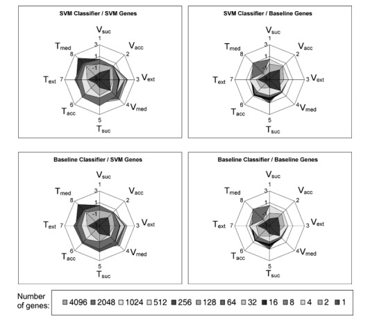

*This figure shows a performance comparison between SVMs and the baseline method using Leukemia data. Classifiers were trained on gene subsets selected by SVMs and the baseline method using the training set of the Leukemia data. The number of genes is color-coded and indicated in the legend. Quality indicators are displayed radially: channels 1–4 show cross-validation results using the leave-one-out method; channels 5–8 show test set results. The indicators include success rate (suc), acceptance rate (acc), extremal margin (ext), and median margin (med). Coefficients are rescaled to have zero mean and variance 1 across all plots. For each classifier, a larger colored area indicates better performance. The figure reveals no significant difference in classifier performance on this dataset, but a significant difference in gene selections.*

**Table 1. Reproduction of Table 6 in Guyon et al. (2002).**

[figure not shown]

*This table presents the performance of the top classifiers on test data consisting of 34 samples. The table includes combinations of SVM or Baseline genes with SVM or Baseline classifiers. For each combination, the table shows the number of selected genes, the number of errors at zero rejection, and the number of rejections at zero error. The number of genes represents the subset selected by the method that provides the best classification performance. Patient ID numbers corresponding to classification errors are indicated in brackets. Additionally, results without any gene selection are provided for comparison.*

**Modern Methods**

Modern feature selection methods have become essential for data preprocessing, extracting the most important information from big data. By reducing the number of features, these methods mitigate the risk of overfitting and enhance the performance of machine learning models and pattern recognition systems (Venkatesh and Anuradha 2019).

Advanced feature selection methods include similarity-based, information-theoretical-based, sparse-learning-based, and statistical-based approaches. Similarity-based approaches select features based on their similarity or dissimilarity, while information-theoretical-based approaches use concepts like entropy and mutual information to evaluate feature importance. Sparse-learning-based approaches focus on identifying a small, essential set of features by limiting the number of features selected, and statistical-based approaches utilize statistical tests and models to determine the significance of features for predicting the target variable (Li et al. 2017).

Early and modern approaches are now categorized into filter, wrapper, embedded, and hybrid approaches. The filter model selects features based on the general properties of the training data, independent of any learning algorithm, making it computationally efficient for large datasets (Das 2001; Kohavi and John 1997). Within the filter model, feature selection algorithms can be further divided into feature weighting algorithms, which assign weights to each feature based on their relevance, and subset search algorithms, which explore candidate feature subsets based on specific evaluation measures (Kohavi and John 1997; Liu and Motoda 2012). The wrapper model, on the other hand, uses a specific learning algorithm to evaluate and determine which features to keep, often leading to better performance but at a higher computational cost (Langley et al. 1994). Embedded methods perform feature selection during the model training process, integrating selection directly with learning. Hybrid methods combine the best aspects of filter and wrapper methods to achieve optimal performance with manageable computational complexity (Venkatesh and Anuradha 2019; Jović, Brkić, and Bogunović 2015).

Feature selection can also be divided into supervised, semi-supervised, and unsupervised categories. Supervised learning involves labeled data, semi-supervised learning utilizes both labeled and unlabeled data, and unsupervised learning works with unlabeled data. Miao and Niu (2016) emphasized that the effectiveness of feature selection methods varies depending on the dataset and model used, necessitating tailored approaches to feature selection.

As feature selection methods evolved, addressing multicollinearity—a scenario where predictor variables are highly correlated—became a critical focus. Traditional methods often assumed independence among features, leading to inaccurate importance measures. Basu and Maji (2022) tackled this issue by introducing a framework to adjust for feature correlations when calculating Shapley values. Their method, termed Multicollinearity Corrected (MCC) Shapley values, provided more accurate measures of feature importance by accounting for existing correlations. Their experiments on datasets with moderate to high feature correlations demonstrated the superiority of MCC Shapley values over non-corrected ones, offering a more reliable interpretation of feature importance in the presence of multicollinearity.

A novel feature selection algorithm leveraging neural networks aims to enhance classification accuracy while reducing computational load by selecting only the most relevant features. This method utilizes feed-forward neural networks (FFNNs) and integrates seamlessly with other classifiers. The algorithm starts with a minimal feature set and iteratively includes additional features based on their contribution to classification accuracy, ensuring that only significant features are selected (Onnia, Tico, and Saarinen 2001).

Experiments on both artificial datasets, like the Monks problems, and real-world datasets, such as the University of Wisconsin Breast Cancer Dataset, the US Congressional Voting Records Dataset, and the Pima Indians Diabetes Dataset, demonstrated significant reductions in the number of features while improving classification accuracy. This approach emphasizes the importance of feature selection in enhancing classification accuracy and reducing computational load, making it a valuable tool for various classification tasks and data collection processes.

In more recent developments, multiple criteria decision-making (MCDM) methods have been applied to feature selection, particularly in the context of text classification with small datasets. Kou et al. (2020) evaluated various feature selection methods using MCDM techniques across multiple text classification datasets. By employing methods like PROMETHEE, they ranked feature selection techniques based on a range of performance measures, including accuracy, stability, and efficiency. Their findings underscored the importance of comprehensive evaluation criteria in selecting the most appropriate feature selection method, tailored to specific dataset characteristics.

The trajectory of feature selection in machine learning illustrates a progression from simple, univariate methods to sophisticated, model-based approaches that address complex issues like multicollinearity and multi-criteria decision making. Early skepticism about “data dredging” has given way to an appreciation of the nuanced techniques necessary for robust predictive modeling. Feature selection methods have evolved to include similarity-based, information-theoretical-based, sparse-learning-based, statistical-based, filter, wrapper, embedded, hybrid, supervised, semi-supervised, and unsupervised approaches. Modern methods, such as neural networks, further enhance the accuracy and efficiency of feature selection, ensuring that only the most relevant features are utilized. As the field continues to advance, it is clear that feature selection will remain a cornerstone of machine learning, improving model performance and reducing computational complexity across a wide range of applications.

# Methods

**Correlation - Based Feature Selection (CFS)**

A common filtering method uses the correlation coefficient to measure the relationship between each variable and the target, independently.

CFS’s feature subset evaluation function is:

$\text{Ms} = \frac{k\bar{\text{rcf}}}{\sqrt k + k(k - 1)\bar{\text{rff}}}$

where Ms is the heuristic ”merit” of a feature subset S containing k features, $\bar{\text{rcf}}$ is the mean feature-class correlation and $\bar{\text{rff}}$ is the average feature - feature intercorrelation. The numerator of this equation reflects the extent to which a set of features is indicative of the class, while the denominator measures the level of redundancy among the features (Hall 1999).

**Recursive Feature Elimination (RFE)**

RFE is a common wrapper method that removes variables iteratively.

For an unknown input vector x, a linear classifier takes the form

$y(x)=$sign$(w⋅x−b)$

The recursive feature elimination method for support vector machines can be executed through these iterative steps(Guyon et al. 2002).

1. Train the SVM classifier
2. compute the ranking criterion for all features
3. remove the features with smallest ranking values

For LS-SVM, substituting the KKT conditions into the Lagrangian gives the objective function

$L = -\frac{1}{2} \sum \sum \alpha_i \alpha_j (K(x_i, x_j) + \frac{\sigma_{ij}}{C}) + \sum \alpha_i y_i$

Where ${\sigma_{ij}} = 1$ if $i=j$ and $0$ otherwise.

The ranking criterion can be obtained by:

$D(L^{-m}) = -\frac{1}{2} \sum \sum \alpha_i \alpha_j (K(x_i, x_j) - (K(x_i^{-m}, x_j^{-m})$

Where $x_i^{-m}$ , $x_j^{-m}$ are the vectors in which $m$-th feature has been removed.

**Least Absolute Shrinkage and Selection Operator (LASSO)**

LASSO is an embedded method that uses L1 Regularization to shrink coefficients to zero, effectively performing feature selection during parameter estimation. LASSO minimizes the sum of squared errors while imposing an upper limit on the sum of the absolute values of the model parameters.

The LASSO estimate is defined by the solution to the l1 optimization problem

minimize $\frac{\| Y - X\beta \|_2^2}{n}$ subject to $X \sum_{j=1}^{k} \|\beta_j\|_1 < t$

where $t$ is the upper bound for the sum of the coefficients (Bühlmann and Van De Geer 2011)

**CFS & RFE**

For the hybrid method, we will combine the filter and wrapper methods; first filtering using the correlation coefficient and then removing variables iteratively using RFE.

# Analysis and Results

```r
# #| include: false
#environment setup (hidden from output)
library(dplyr)
library(quanteda)
library(caret)
library(wordcloud)
library(ggplot2)
library(glmnet)
library(jsonlite)
library(knitr)
library(kableExtra)

# Global parameter to force overwriting of existing cache files
FORCE_OVERWRITE <- FALSE

baseline_lambda = 0
baseline_maxit = 1000000
baseline_alpha = 0
validation_folds = 10

# Function to cache parameters
cache_parameter <- function(name, value = NULL, path = "cache/", prefix = "param_") {
  # Ensure the cache directory exists
  if (!dir.exists(path)) {
    dir.create(path, recursive = TRUE)
  }

  # Construct the full file name
  file_name <- paste0(path, prefix, name, ".json")

  # Check for file existence
  if (file.exists(file_name) && !FORCE_OVERWRITE) {
    # Load and return the value from the file
    cached_value <- fromJSON(file_name)
    # Cast to the appropriate type
    if (cached_value$type == "numeric") {
      return(as.numeric(cached_value$value))
    } else if (cached_value$type == "integer") {
      return(as.integer(cached_value$value))
    } else if (cached_value$type == "list") {
      return(as.list(cached_value$value))
    } else if (cached_value$type == "vector_numeric") {
      return(as.numeric(cached_value$value))
    } else if (cached_value$type == "vector_integer") {
      return(as.integer(cached_value$value))
    } else if (cached_value$type == "named_list_numeric") {
      return(as.list(setNames(as.numeric(cached_value$value), cached_value$names)))
    } else {
      stop("Unsupported cached value type.")
    }
  } else {
    cached_value <- NULL
  }

  if (is.null(value)) {
    return(cached_value)
  } else {
    # Determine the type of the value and write it to the file
    if (is.numeric(value) && length(value) == 1) {
      value_type <- "numeric"
    } else if (is.integer(value) && length(value) == 1) {
      value_type <- "integer"
    } else if (is.list(value)) {
      if (!is.null(names(value)) && all(sapply(value, is.numeric))) {
        value_type <- "named_list_numeric"
      } else {
        value_type <- "list"
      }
    } else if (is.numeric(value) && length(value) > 1) {
      value_type <- "vector_numeric"
    } else if (is.integer(value) && length(value) > 1) {
      value_type <- "vector_integer"
    } else {
      stop("Unsupported value type. Only numeric, integer, vectors, and list are supported.")
    }

    # Prepare the data to be written as JSON
    if (value_type == "named_list_numeric") {
      json_data <- list(type = value_type, value = unname(value), names = names(value))
    } else {
      json_data <- list(type = value_type, value = value)
    }

    # Write the value to the file as JSON
    write_json(json_data, file_name)

    # Return the value
    return(value)
  }
}

geometric_sizes <- function(start_size, end_size, num_steps) {
  ratio <- (end_size / start_size)^(1 / (num_steps - 1))
  sizes <- start_size * (ratio ^ (0:(num_steps - 1)))
  return(round(sizes))
}

# Calculate performance score function
calculate_binary_performance <- function(actual, predicted) {
  confusion <- confusionMatrix(predicted, actual)
  performance <- confusion$overall['Accuracy']
  return(performance)
}


# Function to return the list of features with non-zero coefficients
nonzero_feature_indicies <- function(model, lambda) {
  coefs <- coef(model, s = lambda)
  nonzero_indices <- which(coefs != 0)
  # Exclude the intercept (first coefficient)
  nonzero_indices <- nonzero_indices[-1]
  return(nonzero_indices)
}


# Function to calculate performance at different thresholds
CFS_binary_logistic <- function(X, y, num_folds, num_bins, min_vars, geometric_spacing) {

  y_levels <- levels(y)  # Get the levels from y

  # Step 1: Calculate correlations
  correlations <- apply(X, 2, function(x) cor(x, as.numeric(y)))
  abs_correlations <- abs(correlations)

  # Step 2: Select features based on a correlation threshold
  select_features <- function(threshold) {
    selected_features <- which(abs_correlations >= threshold)
    return(selected_features)
  }

  # Step 3: Sweep through various thresholds and perform 10-fold cross-validation
  if (geometric_spacing){
    sizes <- geometric_sizes(ncol(X), min_vars, num_bins)
  }
  else {
    sizes <- round(seq(from = ncol(X), to = min_vars, length.out = num_bins))
  }

  percentiles <- 1 - sizes / ncol(X)
  thresholds <- quantile(abs_correlations, percentiles)
  results <- list()

  for (threshold in thresholds) {
    selected_features <- select_features(threshold)

    if (length(selected_features) == 0) {
      next
    }

    X_selected <- X[, selected_features, drop = FALSE]

    if (ncol(X_selected) < 2) {
      next
    }

    # Perform k-fold cross-validation
    # train_control <- trainControl(method = "cv", number = num_folds, verboseIter = TRUE)

    scores <- c()

    for (i in 1:num_folds) {
      folds <- createFolds(y, k = num_folds, list = TRUE, returnTrain = TRUE)
      fold_scores <- c()

      for (j in 1:num_folds) {
        train_index <- folds[[j]]
        test_index <- setdiff(seq_len(nrow(X_selected)), train_index)

        x_train_cv <- X_selected[train_index, ]
        y_train_cv <- y[train_index]
        x_test_cv <- X_selected[test_index, ]
        y_test_cv <- y[test_index]
        model_cv <- glmnet(x_train_cv, y_train_cv, maxit = baseline_maxit, lambda.min.ratio = baseline_lambda, alpha = baseline_alpha, family = "binomial", parallel = TRUE)

        pred_cv <- predict(model_cv, x_test_cv, s = min(model_cv$lambda), type = "response")
        pred_cv <- factor(ifelse(pred_cv > 0.5, y_levels[2], y_levels[1]), levels = y_levels)

        fold_scores <- c(fold_scores, calculate_binary_performance(y_test_cv, pred_cv))
      }

      scores <- c(scores, mean(fold_scores))
    }

    feature_indices <- toJSON(selected_features)
    results[[feature_indices]] <- mean(scores)
  }

  return(results)
}


RFE_binary_logistic <- function(X, y, num_folds, num_bins, min_vars, geometric_spacing) {
  results <- list()

  y_levels <- levels(y)  # Get the levels from y

  if (geometric_spacing){
    sizes <- geometric_sizes(ncol(X), min_vars, num_bins)
  }
  else {
    sizes <- round(seq(from = ncol(X), to = min_vars, length.out = num_bins))
  }

  current_features <- seq_len(ncol(X))  # Start with all features

  for (size in sizes) {
    cat("Evaluating size:", size, "\n")

    # Fit glmnet model to get coefficients
    model <- glmnet(X[, current_features, drop = FALSE], y, family = "binomial", alpha = baseline_alpha, maxit = baseline_maxit, lambda.min.ratio = baseline_lambda)
    coefs <- as.matrix(coef(model, s = model$lambda.min))

    # Get indices of the top 'size' features by their absolute coefficient values
    if (length(current_features) > size) {
      selected_features <- order(abs(coefs[-1, 1]), decreasing = TRUE)[1:size]
      current_features <- current_features[selected_features]
    }

    x_selected <- X[, current_features, drop = FALSE]

    folds <- createFolds(y, k = num_folds, list = TRUE, returnTrain = TRUE)
    scores <- c()

    for (fold_idx in seq_along(folds)) {
      train_idx <- folds[[fold_idx]]
      test_idx <- setdiff(seq_len(nrow(x_selected)), train_idx)

      x_train_cv <- x_selected[train_idx, ]
      y_train_cv <- y[train_idx]
      x_test_cv <- x_selected[test_idx, ]
      y_test_cv <- y[test_idx]

      model_cv <- glmnet(x_train_cv, y_train_cv, family = "binomial", alpha = baseline_alpha, maxit = baseline_maxit, lambda.min.ratio = baseline_lambda)

      if (length(model_cv$lambda) == 0) {
        next
      }

      pred_cv_prob <- predict(model_cv, x_test_cv, s = min(model_cv$lambda), type = "response")
      pred_cv <- factor(ifelse(pred_cv_prob > 0.5, y_levels[2], y_levels[1]), levels = y_levels)

      scores <- c(scores, calculate_binary_performance(y_test_cv, pred_cv))
    }

    mean_score <- mean(scores, na.rm = TRUE)
    feature_indices <- toJSON(current_features)
    results[[feature_indices]] <- mean_score
  }

  return(results)
}

subset_performance <- function(named_list) {
  # Extract lengths of the lists and corresponding performance scores
  lengths <- sapply(names(named_list), function(x) {
    list_obj <- fromJSON(x)
    length(list_obj)
  })

  performance <- as.numeric(named_list)

  # Create a data frame for plotting
  data <- data.frame(lengths = lengths, performance = performance)

  return(data)
}

download_and_extract_zip <- function(url, dest_dir) {
  # Ensure the destination directory exists
  if (!dir.exists(dest_dir)) {
    dir.create(dest_dir, recursive = TRUE)
  }

  # Create a temporary file to hold the downloaded zip file
  temp_zip <- tempfile(fileext = ".zip")

  # Download the zip file
  download.file(url, temp_zip, mode = "wb")

  # Extract the contents of the zip file
  unzip(temp_zip, exdir = dest_dir)

  # Remove the temporary zip file
  unlink(temp_zip)
}

download_kaggle_dataset <- function(dataset, path) {
  # Check if the kaggle command is available
  if (system("which kaggle", intern = TRUE) == "") {
    stop("Kaggle API is not installed or not in PATH. Please install it first.")
  }

  # Ensure the destination directory exists
  if (!dir.exists(path)) {
    dir.create(path, recursive = TRUE)
  }

  # Construct the download command
  command <- sprintf("kaggle datasets download -d %s -p %s", dataset, path)

  # Execute the command
  system(command)

  # Unzip the downloaded file
  zipfile <- list.files(path, pattern = "*.zip", full.names = TRUE)
  if (length(zipfile) > 0) {
    unzip(zipfile, exdir = path)
    file.remove(zipfile)
  }
}

# download datasets, if necessary
# download_and_extract_zip("https://archive.ics.uci.edu/static/public/94/spambase.zip", "./data/spambase")
# download_kaggle_dataset("datatattle/covid-19-nlp-text-classification", "./data/covid")
```

## Data Discussion

We evaluated the performance of the methods on two classification tasks. The datasets and associated tasks used were:

**Spambase Dataset**

The Spambase dataset from the UCI Machine Learning Repository contains 4601 instances of emails, with 57 features for classification tasks to determine whether an email is spam or not (Figure 1). Features include word and character frequency counts, as well as measures of consecutive capital letters. It is commonly used for building and testing spam detection models (Hopkins and Suermondt 1999).

```r
#Importing Spam Data
last_57_lines <- tail(readLines("./data/spambase/spambase.names"), 57)
# Function to extract and sanitize column names
extract_column_names <- function(line) {
  # Extract the name before the colon
  name <- strsplit(line, ":")[[1]][1]
  # Sanitize the name by replacing special characters with underscores
  sanitized_name <- gsub("[^a-zA-Z0-9_]", "_", name)
  return(sanitized_name)
}

# Apply the function to each line to get the column names
raw_column_names <- c(sapply(last_57_lines, extract_column_names), 'flag_spam')


# Ensure unique column names
unique_column_names <- make.unique(raw_column_names)
spam_data <- read.csv("./data/spambase/spambase.data", header = FALSE, col.names = unique_column_names) %>%
  mutate(flag_spam = factor(flag_spam, levels = c(0, 1), labels = c("Not Spam", "Spam")))
```

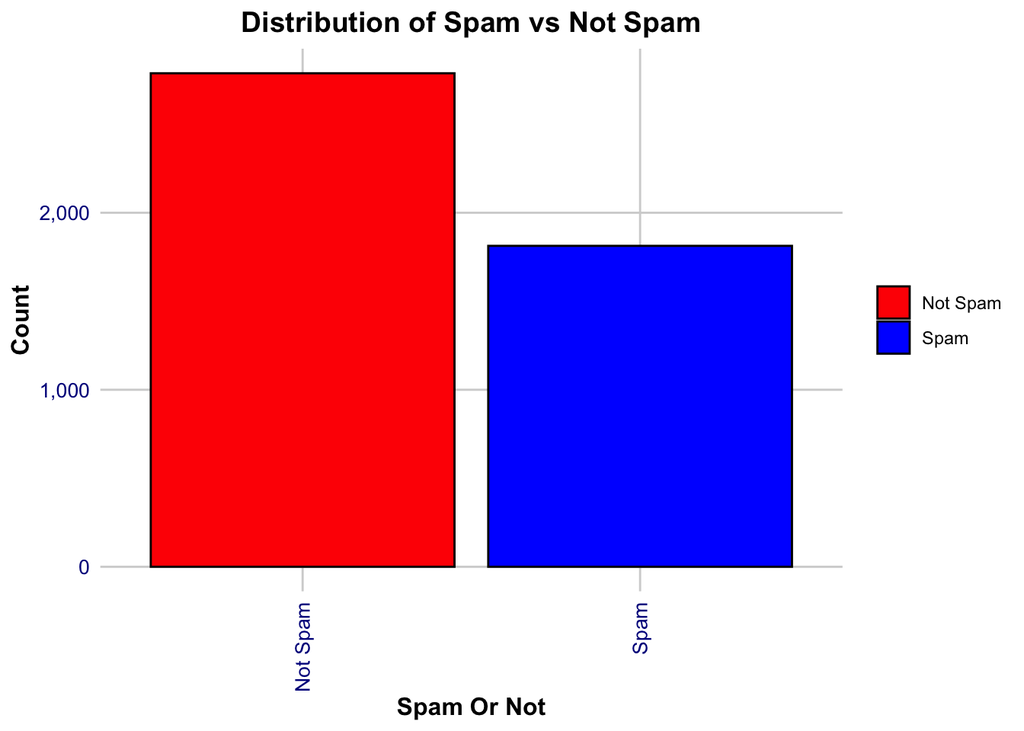

```r
ggplot(spam_data, aes(x = flag_spam, fill = flag_spam)) +
  geom_bar(color = "black") +
  theme_minimal() +
  theme(
    axis.text.x = element_text(angle = 90, hjust = 1, vjust = 0.5, size = 10, color = "darkblue"),
    axis.text.y = element_text(size = 10, color = "darkblue"),
    axis.title.x = element_text(size = 12, face = "bold"),
    axis.title.y = element_text(size = 12, face = "bold"),
    plot.title = element_text(size = 14, face = "bold", hjust = 0.5),
    panel.grid.major = element_line(color = "lightgrey"),
    panel.grid.minor = element_blank()
  ) +
  labs(x = "Spam Or Not", y = "Count", title = "Distribution of Spam vs Not Spam") +
  scale_y_continuous(labels = scales::comma) +
  scale_x_discrete(labels = c("Not Spam" = "Not Spam", "Spam" = "Spam")) +
  scale_fill_manual(values = c("Not Spam" = "red", "Spam" = "blue")) +
  guides(fill = guide_legend(title = NULL))
```

*Figure 1. Frequency of spam targets.*

**COVID-19 NLP Text Classification Dataset**

The COVID-19 NLP Text Classification dataset on Kaggle consists of tweets related to COVID-19, labeled for sentiment analysis. It includes features like tweet content, sentiment labels (positive, negative, neutral), and additional metadata. This dataset is designed for natural language processing tasks to analyze public sentiment during the pandemic (DataTattle 2024).

We recoded sentiment labels to simplify the classification task: “Extremely Negative” and “Extremely Positive” are combined with “Negative” and “Positive” respectively, and “Neutral” sentiments are filtered out (Figure 2). We then processed the text into a “bag of words”. In a “bag of words” NLP classification task, text data is converted into a matrix of word frequencies or occurrences, where each row represents a document and each column represents a unique word from the entire corpus. The classification model then uses this matrix to predict the category of each document. We processed the text by tokenizing the tweets, removing punctuation, numbers, and symbols, converting to lowercase, removing English stopwords, and stemming the words. This results in a Document-Feature Matrix (DFM), which is further refined by trimming infrequent terms in the training data and matching the test data features to those in the training set (9% of data was held out for testing). The distribution of words per “bag” is illustrated in Figure 3.

One of the primary challenges in this approach is data sparsity, as most documents contain only a small subset of all possible words, resulting in a sparse matrix with many zero entries. Additionally, the size of the feature space can become extremely large, especially with extensive vocabularies, which can lead to increased computational demands, memory consumption, and the risk of overfitting, necessitating feature selection or dimensionality reduction techniques.

```r
# Importing Train Data
corona_train <- read.csv("./data/covid/Corona_NLP_train.csv")[, c("OriginalTweet", "Sentiment")]

# Importing Test Data
corona_test <- read.csv("./data/covid/Corona_NLP_test.csv")[, c("OriginalTweet", "Sentiment")]

# Recode Sentiment to factors
corona_train <- corona_train %>%
  filter(Sentiment != "Neutral") %>%
  mutate(Sentiment = recode(Sentiment,
                            "Extremely Negative" = "Negative",
                            "Extremely Positive" = "Positive"),
         Sentiment = factor(Sentiment, levels = c("Negative", "Positive")))

corona_test <- corona_test %>%
  filter(Sentiment != "Neutral") %>%
  mutate(Sentiment = recode(Sentiment,
                            "Extremely Negative" = "Negative",
                            "Extremely Positive" = "Positive"),
         Sentiment = factor(Sentiment, levels = c("Negative", "Positive")))

# Preprocessing and tokenization using quanteda
preprocess_text <- function(text_column) {
  tokens <- tokens(text_column,
                   what = "word",
                   remove_punct = TRUE,
                   remove_numbers = TRUE,
                   remove_symbols = TRUE) %>%
    tokens_tolower() %>%
    tokens_remove(stopwords("english")) %>%
    tokens_wordstem()

  # Create a Document-Feature Matrix (DFM)
  dfm <- dfm(tokens)

  return(dfm)
}

corona_train_dfm <- dfm_trim(preprocess_text(corona_train$OriginalTweet), min_termfreq = 10)
corona_test_dfm <- dfm_match(preprocess_text(corona_test$OriginalTweet), features = featnames(corona_train_dfm))

# Convert DFM to sparse matrix
corona_train_sparse <- as(corona_train_dfm, "dgCMatrix")
corona_test_sparse <- as(corona_test_dfm, "dgCMatrix")
```

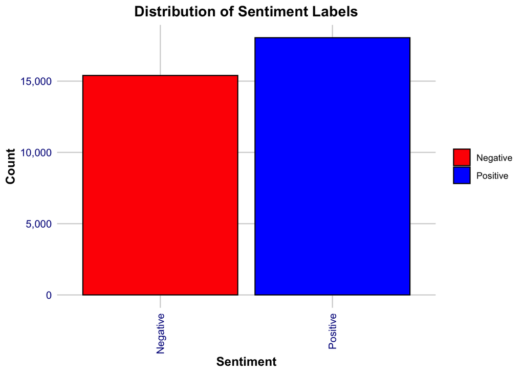

```r
ggplot(corona_train, aes(x = Sentiment, fill = Sentiment)) +
  geom_bar(color = "black") +
  theme_minimal() +
  theme(
    axis.text.x = element_text(angle = 90, hjust = 1, vjust = 0.5, size = 10, color = "darkblue"),
    axis.text.y = element_text(size = 10, color = "darkblue"),
    axis.title.x = element_text(size = 12, face = "bold"),
    axis.title.y = element_text(size = 12, face = "bold"),
    plot.title = element_text(size = 14, face = "bold", hjust = 0.5),
    panel.grid.major = element_line(color = "lightgrey"),
    panel.grid.minor = element_blank()
  ) +
  labs(x = "Sentiment", y = "Count", title = "Distribution of Sentiment Labels") +
  scale_y_continuous(labels = scales::comma) +
  scale_x_discrete(labels = c("Positive" = "Positive", "Negative" = "Negative")) +
  scale_fill_manual(values = c("Negative" = "red", "Positive" = "blue")) +
  guides(fill = guide_legend(title = NULL))
```

*Figure 2. Frequency of sentiment targets.*

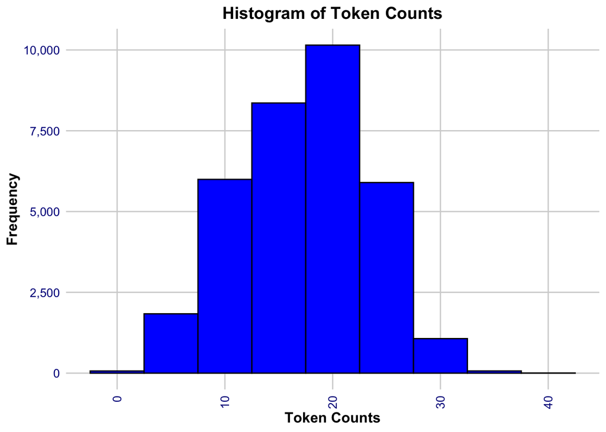

```r
# Calculate and visualize mean, standard deviation, and range of tokens per document
token_counts <- rowSums(corona_train_dfm)

ggplot(data = data.frame(token_counts), aes(x = token_counts)) +
  geom_histogram(binwidth = 5, color = "black", fill = "blue") +
  theme_minimal() +
  theme(
    axis.text.x = element_text(angle = 90, hjust = 1, vjust = 0.5, size = 10, color = "darkblue"),
    axis.text.y = element_text(size = 10, color = "darkblue"),
    axis.title.x = element_text(size = 12, face = "bold"),
    axis.title.y = element_text(size = 12, face = "bold"),
    plot.title = element_text(size = 14, face = "bold", hjust = 0.5),
    panel.grid.major = element_line(color = "lightgrey"),
    panel.grid.minor = element_blank()
  ) +
  labs(title = "Histogram of Token Counts",
       x = "Token Counts",
       y = "Frequency") +
  scale_y_continuous(labels = scales::comma)
```

*Figure 3. Distribution of words per Tweet.*

## Statistical Modeling

We evaluated the feature selection methods using three metrics:

- **Accuracy** on the test set.
- Difference between accuracy on the training and test set (**overfitting**).
- Number of variables selected (model **complexity**).

To establish a baseline for performance, we first trained a binomial logistic regression model using all available variables. We then use the four selection methods, training a binomial logistic regression model on the features selected with each method. In total, we produced 5 models for each dataset:

Figure 5 illustrates parameter tuning using the twenty thresholds. In this example, a threshold that selected just under 2,000 features was used. Note the geometric progression in threshold selections; we selected thresholds in a way that removed a fixed proportion of features, in contrast to removing a fixed number of features. In figure 6, we see an example of the LASSO model selecting features by forcing parameter estimates to zero as the L1 Norm decreases.

```r
set.seed(42)

# Create a train-test split
trainIndex <- sample(1:nrow(spam_data), size = 0.8 * nrow(spam_data))

# Split the data
spam_train <- spam_data[trainIndex, ]
spam_test <- spam_data[-trainIndex, ]

X_train_raw <- spam_train %>% select(-flag_spam)
X_test_raw  <- spam_test %>% select(-flag_spam)

y_train  <- spam_train$flag_spam
y_test <- spam_test$flag_spam

levels = levels(y_train)

# scale the data, calculate all two-way interactions, and drop the intercept
preprocess_params <- preProcess(X_train_raw, method = c("center", "scale"))
X_train <- model.matrix( ~ .^2, predict(preprocess_params, X_train_raw))[, -1]
X_test <- model.matrix( ~ .^2, predict(preprocess_params, X_test_raw))[, -1]

spam_num_features <- ncol(X_train)
spam_num_records<- nrow(X_train)
num_nonzero <- sum(model.matrix( ~ .^2, X_train_raw)[, -1] != 0)
total_elements <- prod(dim(X_train))
spam_sparsity <- ((total_elements - num_nonzero) / total_elements) * 100


baseline_model <- glmnet(
  X_train,
  y_train,
  family = "binomial",
  alpha = baseline_alpha,
  lambda.min.ratio = baseline_lambda,
  maxit = baseline_maxit,
  parallel = TRUE
)

# Predict on training and test datasets
train_predictions_prob <- predict(baseline_model, X_train, s = min(baseline_model$lambda), type = "response")
test_predictions_prob <- predict(baseline_model, X_test, s = min(baseline_model$lambda), type = "response")

# Convert probabilities to class labels (0 or 1)
train_predictions <- factor(ifelse(train_predictions_prob > 0.5, levels[2], levels[1]), levels = levels)
test_predictions <- factor(ifelse(test_predictions_prob > 0.5, levels[2], levels[1]), levels = levels)

# Calculate accuracy scores for training and test datasets
train_accuracy_score <- calculate_binary_performance(spam_train$flag_spam, train_predictions)
test_accuracy_score <- calculate_binary_performance(spam_test$flag_spam, test_predictions)

# Calculate the number of features
num_features <- ncol(X_train)
non_zero_features <- length(nonzero_feature_indicies(baseline_model, min(baseline_model$lambda)))

# Calculate the difference in accuracy score between train and test data
accuracy_difference <- train_accuracy_score - test_accuracy_score

#save the results
spam_baseline_non_zero_features <- non_zero_features
spam_baseline_test_accuracy_score <- test_accuracy_score
spam_baseline_accuracy_difference <- accuracy_difference



#CORRELATION FEATURE SELECTION
cfs_feature_subsets <- cache_parameter('spam_cfs_feature_subsets')
if (is.null(cfs_feature_subsets)) {
  cfs_feature_subsets <- cache_parameter('spam_cfs_feature_subsets', CFS_binary_logistic(X_train, y_train, num_folds=validation_folds, num_bins = 20, min_vars = 50, geometric_spacing = TRUE))
}
optimal_subset <- fromJSON(names(cfs_feature_subsets)[which.max(cfs_feature_subsets)])

# Step 4: Use the optimal threshold to train the final model
X_train_selected <- X_train[, optimal_subset, drop=FALSE]
X_test_selected <- X_test[, optimal_subset, drop=FALSE]

spam_num_features1 <- ncol(X_train_selected)
num_nonzero <- sum(model.matrix( ~ .^2, X_train_raw)[, -1][, optimal_subset, drop=FALSE] != 0)
total_elements <- prod(dim(X_train_selected))
spam_sparsity1 <- ((total_elements - num_nonzero) / total_elements) * 100

final_model <- glmnet(X_train_selected, y_train, family = "binomial", alpha = baseline_alpha, maxit = baseline_maxit, lambda.min.ratio = baseline_lambda, parallel = TRUE)

# Predict on training and test datasets
train_predictions_prob <- predict(final_model, X_train_selected, s = min(final_model$lambda), type = "response")
test_predictions_prob <- predict(final_model, X_test_selected, s = min(final_model$lambda), type = "response")

# Convert probabilities to class labels (0 or 1)
train_predictions <- factor(ifelse(train_predictions_prob > 0.5, levels[2], levels[1]), levels = levels)
test_predictions <- factor(ifelse(test_predictions_prob > 0.5, levels[2], levels[1]), levels = levels)

# Calculate accuracy scores for training and test datasets
train_accuracy_score <- calculate_binary_performance(spam_train$flag_spam, train_predictions)
test_accuracy_score <- calculate_binary_performance(spam_test$flag_spam, test_predictions)

# Calculate the number of features
num_features <- ncol(X_train_selected)
non_zero_features <- length(nonzero_feature_indicies(final_model, min(final_model$lambda)))

# Calculate the difference in accuracy score between train and test data
accuracy_difference <- train_accuracy_score - test_accuracy_score

# save the results
spam_cfs_non_zero_features <- non_zero_features
spam_cfs_test_accuracy_score <- test_accuracy_score
spam_cfs_accuracy_difference <- accuracy_difference
spam_cfs_plot_data <- subset_performance(cfs_feature_subsets)


# RECURSIVE FEATURE ELIMINATION

feature_subsets <- cache_parameter('spam_rfe_feature_subsets')
if (is.null(feature_subsets)) {
  feature_subsets <- cache_parameter('spam_rfe_feature_subsets', RFE_binary_logistic(X_train, y_train, num_folds=validation_folds, num_bins = 20, min_vars = 50, geometric_spacing = TRUE))
}
optimal_subset <- fromJSON(names(feature_subsets)[which.max(feature_subsets)])

# Fit the final model using selected features
X_train_selected = X_train[, optimal_subset, drop=FALSE]
X_test_selected = X_test[, optimal_subset, drop=FALSE]

spam_num_features2 <- ncol(X_train_selected)
num_nonzero <- sum(model.matrix( ~ .^2, X_train_raw)[, -1][, optimal_subset, drop=FALSE] != 0)
total_elements <- prod(dim(X_train_selected))
spam_sparsity2 <- ((total_elements - num_nonzero) / total_elements) * 100

final_model <- glmnet(X_train_selected, y_train, family = "binomial", alpha = baseline_alpha, maxit = baseline_maxit, lambda.min.ratio = baseline_lambda)

# Predict on training and test datasets
train_predictions_prob <- predict(final_model, newx = X_train_selected, s = min(final_model$lambda), type = "response")
test_predictions_prob <- predict(final_model, newx = X_test_selected, s = min(final_model$lambda), type = "response")

# Convert probabilities to class labels (0 or 1)
train_predictions <- factor(ifelse(train_predictions_prob > 0.5, levels[2], levels[1]), levels = levels)
test_predictions <- factor(ifelse(test_predictions_prob > 0.5, levels[2], levels[1]), levels = levels)
```

```r
# Calculate accuracy scores for training and test datasets
train_accuracy_score <- calculate_binary_performance(spam_train$flag_spam, train_predictions)
test_accuracy_score <- calculate_binary_performance(spam_test$flag_spam, test_predictions)

# Calculate the number of features
num_features <- ncol(X_train_selected)
non_zero_features <- length(nonzero_feature_indicies(final_model, min(final_model$lambda)))

# Calculate the difference in accuracy score between train and test data
accuracy_difference <- train_accuracy_score - test_accuracy_score

# save the results
spam_rfe_non_zero_features <- non_zero_features
spam_rfe_test_accuracy_score <- test_accuracy_score
spam_rfe_accuracy_difference <- accuracy_difference
spam_rfe_plot_data <- subset_performance(feature_subsets)


#LASSO REGRESSION
lambdas <- cache_parameter('spam_lasso_lambdas')
feature_subsets_sizes <- cache_parameter('spam_lasso_feature_subsets_sizes')
if (is.null(lambdas)) {
  cv_lasso <- cv.glmnet(X_train, y_train, family = "binomial", alpha = 1, maxit = baseline_maxit, nfolds = validation_folds)
  lambda_values <- cv_lasso$lambda
  non_zero_features <- sapply(lambda_values, nonzero_feature_indicies, model = cv_lasso)
  non_zero_feature_sizes <- sapply(non_zero_features, length)
  performance <- cv_lasso$cvm
  lambdas <- cache_parameter('spam_lasso_lambdas', setNames(as.list(performance), as.character(lambda_values)))
  feature_subsets_sizes <- cache_parameter('spam_lasso_feature_subsets_sizes', setNames(as.list(performance), as.character(non_zero_feature_sizes)))
}
optimal_lambda <- as.double(names(lambdas)[which.min(lambdas)])


# Fit the final Lasso model using the best lambda
spam_lasso_final_model <- glmnet(X_train, y_train, family = "binomial", maxit = baseline_maxit, alpha = 1, lambda.min.ratio = optimal_lambda)

# Predict on training and test datasets
train_predictions_prob <- predict(spam_lasso_final_model, newx = X_train, s = optimal_lambda, type = "response")
test_predictions_prob <- predict(spam_lasso_final_model, newx = X_test, s = optimal_lambda, type = "response")

# Convert probabilities to class labels (0 or 1)
train_predictions <- factor(ifelse(train_predictions_prob > 0.5, levels[2], levels[1]), levels = levels)
test_predictions <- factor(ifelse(test_predictions_prob > 0.5, levels[2], levels[1]), levels = levels)

# Calculate accuracy scores for training and test datasets
train_accuracy_score <- calculate_binary_performance(spam_train$flag_spam, train_predictions)
test_accuracy_score <- calculate_binary_performance(spam_test$flag_spam, test_predictions)

# Calculate the number of features
num_features <- ncol(X_train)
non_zero_features <- length(nonzero_feature_indicies(spam_lasso_final_model, min(spam_lasso_final_model$lambda)))

spam_num_features3 <- non_zero_features

# Calculate the difference in accuracy score between train and test data
accuracy_difference <- train_accuracy_score - test_accuracy_score

# Save the results
spam_lasso_non_zero_features <- non_zero_features
spam_lasso_test_accuracy_score <- test_accuracy_score
spam_lasso_accuracy_difference <- accuracy_difference
spam_lasso_plot_data <- data.frame(lengths = as.integer(names(feature_subsets_sizes)), performance = as.numeric(feature_subsets_sizes))
spam_lasso_plot_data_lambda <- data.frame(lengths = as.integer(names(feature_subsets_sizes)), lambdas = as.double(names(lambdas)))


#CFS + RFE REGRESSION

starting_features = fromJSON(names(cfs_feature_subsets)[3])
feature_subsets <- cache_parameter('spam_cfs_rfe_feature_subsets')
if (is.null(feature_subsets)) {
  X_train_cfs_selected <- X_train[, starting_features, drop = FALSE]
  feature_subsets <- cache_parameter('spam_cfs_rfe_feature_subsets', RFE_binary_logistic(X_train_cfs_selected, y_train, num_folds=validation_folds, num_bins = 20, min_vars = 50, geometric_spacing = FALSE))
}
optimal_subset <- fromJSON(names(feature_subsets)[which.max(feature_subsets)])

# Fit the final model using selected features
X_train_selected = X_train[, optimal_subset, drop=FALSE]
X_test_selected = X_test[, optimal_subset, drop=FALSE]

spam_num_features4 <- ncol(X_train_selected)
num_nonzero <- sum(model.matrix( ~ .^2, X_train_raw)[, -1][, optimal_subset, drop=FALSE] != 0)
total_elements <- prod(dim(X_train_selected))
spam_sparsity4 <- ((total_elements - num_nonzero) / total_elements) * 100

final_model <- glmnet(X_train_selected, y_train, family = "binomial", alpha = baseline_alpha, maxit = baseline_maxit, lambda.min.ratio = baseline_lambda)

# Predict on training and test datasets
train_predictions_prob <- predict(final_model, newx = X_train_selected, s = min(final_model$lambda), type = "response")
test_predictions_prob <- predict(final_model, newx = X_test_selected, s = min(final_model$lambda), type = "response")

# Convert probabilities to class labels (0 or 1)
train_predictions <- factor(ifelse(train_predictions_prob > 0.5, levels[2], levels[1]), levels = levels)
test_predictions <- factor(ifelse(test_predictions_prob > 0.5, levels[2], levels[1]), levels = levels)

# Calculate accuracy scores for training and test datasets
train_accuracy_score <- calculate_binary_performance(spam_train$flag_spam, train_predictions)
test_accuracy_score <- calculate_binary_performance(spam_test$flag_spam, test_predictions)

# Calculate the number of features
num_features <- ncol(X_train_selected)
non_zero_features <- length(nonzero_feature_indicies(final_model, min(final_model$lambda)))

# Calculate the difference in accuracy score between train and test data
accuracy_difference <- train_accuracy_score - test_accuracy_score

# save results
spam_cfs_rfe_non_zero_features <- non_zero_features
spam_cfs_rfe_test_accuracy_score <- test_accuracy_score
spam_cfs_rfe_accuracy_difference <- accuracy_difference
spam_cfs_rfe_plot_data <- subset_performance(feature_subsets)
```

```r
set.seed(42)

# Convert DFM to sparse matrix
train_sparse <- corona_train_sparse
test_sparse <- corona_test_sparse

# Convert Sentiment to numeric for glmnet
y_train <- corona_train$Sentiment
y_test <- corona_test$Sentiment

levels = levels(y_train)

covid_num_features <- ncol(train_sparse)
covid_num_records<- nrow(train_sparse)
num_nonzero <- sum(train_sparse != 0)
total_elements <- prod(dim(train_sparse))
covid_sparsity <- ((total_elements - num_nonzero) / total_elements) * 100

# Fit the logistic regression model with glmnet

baseline_model <- glmnet(
  train_sparse,
  y_train,
  family = "binomial",
  alpha = baseline_alpha,
  lambda.min.ratio = baseline_lambda,
  maxit = baseline_maxit,
  parallel = TRUE
)

# Predict on training and test datasets
train_predictions_prob <- predict(baseline_model, train_sparse, s = min(baseline_model$lambda), type = "response")
test_predictions_prob <- predict(baseline_model, test_sparse, s = min(baseline_model$lambda), type = "response")

# Convert probabilities to class labels (0 or 1)
train_predictions <- factor(ifelse(train_predictions_prob > 0.5, levels[2], levels[1]), levels = levels)
test_predictions <- factor(ifelse(test_predictions_prob > 0.5, levels[2], levels[1]), levels = levels)

# Calculate accuracy scores for training and test datasets
train_accuracy_score <- calculate_binary_performance(corona_train$Sentiment, train_predictions)
test_accuracy_score <- calculate_binary_performance(corona_test$Sentiment, test_predictions)

# Calculate the number of features
num_features <- ncol(train_sparse)
non_zero_features <- length(nonzero_feature_indicies(baseline_model, min(baseline_model$lambda)))

# Calculate the difference in accuracy score between train and test data
accuracy_difference <- train_accuracy_score - test_accuracy_score

# save results
covid_baseline_non_zero_features <- non_zero_features
covid_baseline_test_accuracy_score <- test_accuracy_score
covid_baseline_accuracy_difference <- accuracy_difference

#CORRELATION FEATURE SELECTION
cfs_feature_subsets <- cache_parameter('covid_cfs_feature_subsets')
if (is.null(cfs_feature_subsets)) {
  cfs_feature_subsets <- cache_parameter('covid_cfs_feature_subsets', CFS_binary_logistic(train_sparse, y_train, num_folds=validation_folds, num_bins = 20, min_vars = 50, geometric_spacing = TRUE))
}
optimal_subset <- fromJSON(names(cfs_feature_subsets)[which.max(cfs_feature_subsets)])

# Step 4: Use the optimal threshold to train the final model
train_sparse_selected <- train_sparse[, optimal_subset, drop=FALSE]
test_sparse_selected <- test_sparse[, optimal_subset, drop=FALSE]

covid_num_features1 <- ncol(train_sparse_selected)
num_nonzero <- sum(train_sparse_selected != 0)
total_elements <- prod(dim(train_sparse_selected))
covid_sparsity1 <- ((total_elements - num_nonzero) / total_elements) * 100

final_model <- glmnet(train_sparse_selected, y_train, family = "binomial", alpha = baseline_alpha, maxit = baseline_maxit, lambda.min.ratio = baseline_lambda, parallel = TRUE)

# Predict on training and test datasets
train_predictions_prob <- predict(final_model, train_sparse_selected, s = min(final_model$lambda), type = "response")
test_predictions_prob <- predict(final_model, test_sparse_selected, s = min(final_model$lambda), type = "response")

# Convert probabilities to class labels (0 or 1)
train_predictions <- factor(ifelse(train_predictions_prob > 0.5, levels[2], levels[1]), levels = levels)
test_predictions <- factor(ifelse(test_predictions_prob > 0.5, levels[2], levels[1]), levels = levels)

# Calculate accuracy scores for training and test datasets
train_accuracy_score <- calculate_binary_performance(corona_train$Sentiment, train_predictions)
test_accuracy_score <- calculate_binary_performance(corona_test$Sentiment, test_predictions)

# Calculate the number of features
num_features <- ncol(train_sparse_selected)
non_zero_features <- length(nonzero_feature_indicies(final_model, min(final_model$lambda)))

# Calculate the difference in accuracy score between train and test data
accuracy_difference <- train_accuracy_score - test_accuracy_score

# save the results
covid_cfs_non_zero_features <- non_zero_features
covid_cfs_test_accuracy_score <- test_accuracy_score
covid_cfs_accuracy_difference <- accuracy_difference
covid_cfs_plot_data <- subset_performance(cfs_feature_subsets)


# RECURSIVE FEATURE ELIMINATION

feature_subsets <- cache_parameter('covid_rfe_feature_subsets')
if (is.null(feature_subsets)) {
  feature_subsets <- cache_parameter('covid_rfe_feature_subsets', RFE_binary_logistic(train_sparse, y_train, num_folds=validation_folds, num_bins = 20, min_vars = 50, geometric_spacing = TRUE))
}
optimal_subset <- fromJSON(names(feature_subsets)[which.max(feature_subsets)])

# Fit the final model using selected features
train_sparse_selected = train_sparse[, optimal_subset, drop=FALSE]
test_sparse_selected = test_sparse[, optimal_subset, drop=FALSE]

covid_num_features2 <- ncol(train_sparse_selected)
num_nonzero <- sum(train_sparse_selected != 0)
total_elements <- prod(dim(train_sparse_selected))
covid_sparsity2 <- ((total_elements - num_nonzero) / total_elements) * 100

final_model <- glmnet(train_sparse_selected, y_train, family = "binomial", alpha = baseline_alpha, maxit = baseline_maxit, lambda.min.ratio = baseline_lambda)

# Predict on training and test datasets
train_predictions_prob <- predict(final_model, newx = train_sparse_selected, s = min(final_model$lambda), type = "response")
test_predictions_prob <- predict(final_model, newx = test_sparse_selected, s = min(final_model$lambda), type = "response")

# Convert probabilities to class labels (0 or 1)
train_predictions <- factor(ifelse(train_predictions_prob > 0.5, levels[2], levels[1]), levels = levels)
test_predictions <- factor(ifelse(test_predictions_prob > 0.5, levels[2], levels[1]), levels = levels)

# Calculate accuracy scores for training and test datasets
train_accuracy_score <- calculate_binary_performance(corona_train$Sentiment, train_predictions)
test_accuracy_score <- calculate_binary_performance(corona_test$Sentiment, test_predictions)

# Calculate the number of features
num_features <- ncol(train_sparse_selected)
non_zero_features <- length(nonzero_feature_indicies(final_model, min(final_model$lambda)))

# Calculate the difference in accuracy score between train and test data
accuracy_difference <- train_accuracy_score - test_accuracy_score

# save results
covid_rfe_non_zero_features <- non_zero_features
covid_rfe_test_accuracy_score <- test_accuracy_score
covid_rfe_accuracy_difference <- accuracy_difference
covid_rfe_plot_data <- subset_performance(feature_subsets)


#LASSO REGRESSION
lambdas <- cache_parameter('covid_lasso_lambdas')
feature_subsets_sizes <- cache_parameter('covid_lasso_feature_subsets_sizes')
if (is.null(lambdas)) {
  cv_lasso <- cv.glmnet(train_sparse, y_train, family = "binomial", alpha = 1, maxit = baseline_maxit, nfolds = validation_folds)
  lambda_values <- cv_lasso$lambda
  non_zero_features <- sapply(lambda_values, nonzero_feature_indicies, model = cv_lasso)
  non_zero_feature_sizes <- sapply(non_zero_features, length)
  performance <- cv_lasso$cvm
  lambdas <- cache_parameter('covid_lasso_lambdas', setNames(as.list(performance), as.character(lambda_values)))
  feature_subsets_sizes <- cache_parameter('covid_lasso_feature_subsets_sizes', setNames(as.list(performance), as.character(non_zero_feature_sizes)))
}
optimal_lambda <- as.double(names(lambdas)[which.min(lambdas)])


# Fit the final Lasso model using the best lambda
final_model <- glmnet(train_sparse, y_train, family = "binomial", maxit = baseline_maxit, alpha = 1, lambda.min.ratio = optimal_lambda)

# Predict on training and test datasets
train_predictions_prob <- predict(final_model, newx = train_sparse, s = optimal_lambda, type = "response")
test_predictions_prob <- predict(final_model, newx = test_sparse, s = optimal_lambda, type = "response")

# Convert probabilities to class labels (0 or 1)
train_predictions <- factor(ifelse(train_predictions_prob > 0.5, levels[2], levels[1]), levels = levels)
test_predictions <- factor(ifelse(test_predictions_prob > 0.5, levels[2], levels[1]), levels = levels)

# Calculate accuracy scores for training and test datasets
train_accuracy_score <- calculate_binary_performance(corona_train$Sentiment, train_predictions)
test_accuracy_score <- calculate_binary_performance(corona_test$Sentiment, test_predictions)

# Calculate the number of features
num_features <- ncol(train_sparse)
non_zero_features <- length(nonzero_feature_indicies(final_model, min(final_model$lambda)))

covid_num_features3 <- non_zero_features

# Calculate the difference in accuracy score between train and test data
accuracy_difference <- train_accuracy_score - test_accuracy_score

# Save the results
covid_lasso_non_zero_features <- non_zero_features
covid_lasso_test_accuracy_score <- test_accuracy_score
covid_lasso_accuracy_difference <- accuracy_difference
covid_lasso_plot_data <- data.frame(lengths = as.integer(names(feature_subsets_sizes)), performance = as.numeric(feature_subsets_sizes))
covid_lasso_plot_data_lambda <- data.frame(lengths = as.integer(names(feature_subsets_sizes)), lambdas = as.double(names(lambdas)))

#CFS + RFE REGRESSION

starting_features = fromJSON(names(cfs_feature_subsets)[3])
feature_subsets <- cache_parameter('covid_cfs_rfe_feature_subsets')
if (is.null(feature_subsets)) {
  train_sparse_cfs_selected <- train_sparse[, starting_features, drop = FALSE]
  feature_subsets <- cache_parameter('covid_cfs_rfe_feature_subsets', RFE_binary_logistic(train_sparse_cfs_selected, y_train, num_folds=validation_folds, num_bins = 20, min_vars = 50, geometric_spacing = FALSE))
}
optimal_subset <- fromJSON(names(feature_subsets)[which.max(feature_subsets)])

# Fit the final model using selected features
train_sparse_selected = train_sparse[, optimal_subset, drop=FALSE]
test_sparse_selected = test_sparse[, optimal_subset, drop=FALSE]

covid_num_features4 <- ncol(train_sparse_selected)
num_nonzero <- sum(train_sparse_selected != 0)
total_elements <- prod(dim(train_sparse_selected))
covid_sparsity4 <- ((total_elements - num_nonzero) / total_elements) * 100

final_model <- glmnet(train_sparse_selected, y_train, family = "binomial", alpha = baseline_alpha, maxit = baseline_maxit, lambda.min.ratio = baseline_lambda)

# Predict on training and test datasets
train_predictions_prob <- predict(final_model, newx = train_sparse_selected, s = min(final_model$lambda), type = "response")
test_predictions_prob <- predict(final_model, newx = test_sparse_selected, s = min(final_model$lambda), type = "response")

# Convert probabilities to class labels (0 or 1)
train_predictions <- factor(ifelse(train_predictions_prob > 0.5, levels[2], levels[1]), levels = levels)
test_predictions <- factor(ifelse(test_predictions_prob > 0.5, levels[2], levels[1]), levels = levels)

# Calculate accuracy scores for training and test datasets
train_accuracy_score <- calculate_binary_performance(corona_train$Sentiment, train_predictions)
test_accuracy_score <- calculate_binary_performance(corona_test$Sentiment, test_predictions)

# Calculate the number of features
num_features <- ncol(train_sparse_selected)
non_zero_features <- length(nonzero_feature_indicies(final_model, min(final_model$lambda)))

# Calculate the difference in accuracy score between train and test data
accuracy_difference <- train_accuracy_score - test_accuracy_score

# Save results
covid_cfs_rfe_non_zero_features <- non_zero_features
covid_cfs_rfe_test_accuracy_score <- test_accuracy_score
covid_cfs_rfe_accuracy_difference <- accuracy_difference
covid_cfs_rfe_plot_data <- subset_performance(feature_subsets)
```

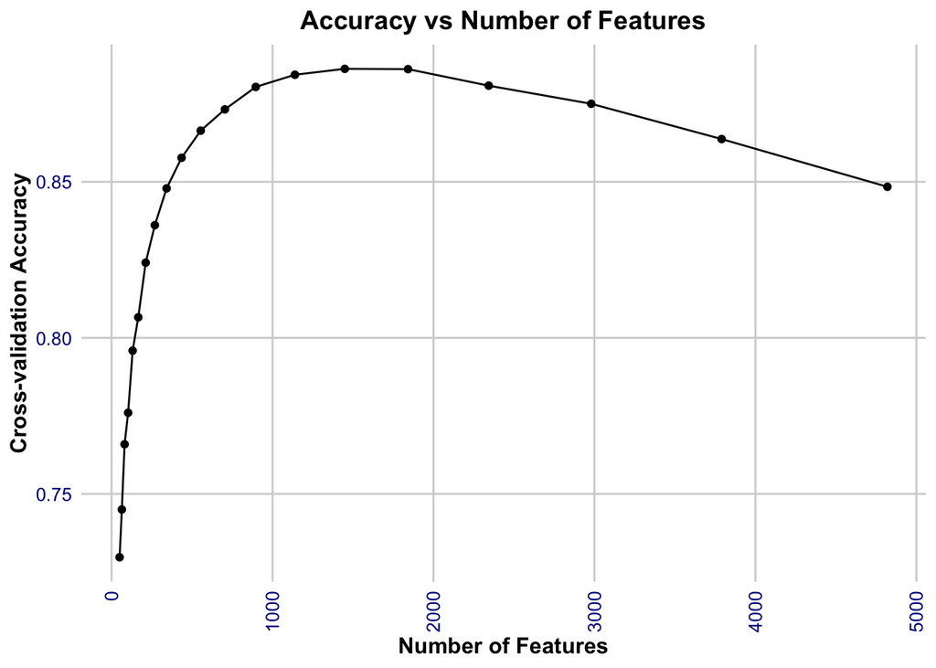

```r
ggplot(covid_cfs_plot_data, aes(x = lengths, y = performance)) +
  geom_point() +
  geom_line() +
  theme_minimal() +
  theme(
    axis.text.x = element_text(angle = 90, hjust = 1, vjust = 0.5, size = 10, color = "darkblue"),
    axis.text.y = element_text(size = 10, color = "darkblue"),
    axis.title.x = element_text(size = 12, face = "bold"),
    axis.title.y = element_text(size = 12, face = "bold"),
    plot.title = element_text(size = 14, face = "bold", hjust = 0.5),
    panel.grid.major = element_line(color = "lightgrey"),
    panel.grid.minor = element_blank()
  ) +
  labs(title = "Accuracy vs Number of Features",
       x = "Number of Features",
       y = "Cross-validation Accuracy") +
  scale_y_continuous(labels = scales::comma)
```

*Figure 4. Example of cross-validation accuracy with CFS model for the Sentiment task.*

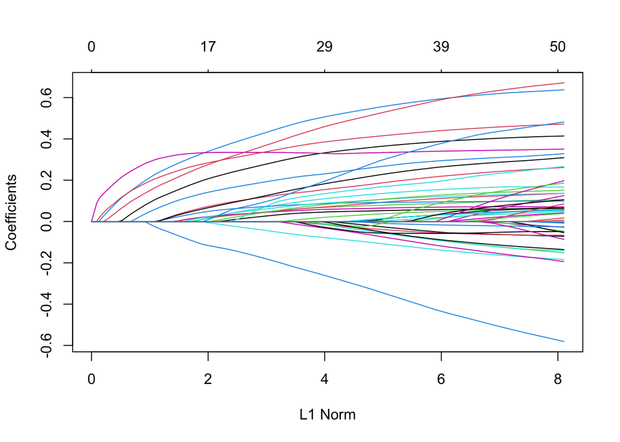

```r
plot(spam_lasso_final_model)
```

*Figure 5. Example of coefficient behavior with LASSO model for the spam task.*

## Results

**Spambase Dataset**

Table 1 displays the results of feature selection for the spam classification task. Each row represents a feature selection method, and the columns represent the various metrics. For model complexity, as measured by number of features, we consider a lower number to be better. For test accuracy, higher is better. And finally, for overfitting, as measured by the difference between the training and test scores, we consider lower better.

As you can see, the baseline performance, without feature selection, has decent performance but is somewhat overfitted. The CFS method produces the best performance and a fairly parsimonious model with only 126 variables. The LASSO model is the most parsimonious, but has the lowest performance suggesting it may have eliminated too many features.

```r
# Create visuals for Spambase dataset
var_method <- c('Baseline', 'CFS', 'RFE', 'LASSO', 'CFS + RFE')
num_features <- c(spam_baseline_non_zero_features, spam_cfs_non_zero_features, spam_rfe_non_zero_features, spam_lasso_non_zero_features, spam_cfs_rfe_non_zero_features)
accuracy_score <- c(spam_baseline_test_accuracy_score, spam_cfs_test_accuracy_score, spam_rfe_test_accuracy_score, spam_lasso_test_accuracy_score, spam_cfs_rfe_test_accuracy_score)
accuracy_diff <- c(spam_baseline_accuracy_difference, spam_cfs_accuracy_difference, spam_rfe_accuracy_difference, spam_lasso_accuracy_difference, spam_cfs_rfe_accuracy_difference)

data <- data.frame(var_method, num_features, accuracy_score, accuracy_diff)

# Format numbers
data <- data %>%
  mutate(
    accuracy_score = round(accuracy_score, 3),
    accuracy_diff = round(accuracy_diff, 3)
  )

# Create and render the table
kable(data, format = "html", col.names = c("Method", "Number of Features", "Test Accuracy Score", "Accuracy Decrease from Train")) %>%
  kable_styling(bootstrap_options = c("striped", "hover", "condensed", "responsive"))
```

| Method | Number of Features | Test Accuracy Score | Accuracy Decrease from Train |
| --- | --- | --- | --- |
| Baseline | 1653 | 0.915 | 0.070 |
| CFS | 126 | 0.936 | -0.004 |
| RFE | 1144 | 0.911 | 0.067 |
| LASSO | 50 | 0.903 | -0.006 |
| CFS + RFE | 683 | 0.920 | 0.045 |

*Table 1. Results of spam classification task.*

**COVID-19 NLP Text Classification Dataset**

```r
# Create visuals for Covid dataset
var_method <- c('Baseline', 'CFS', 'RFE', 'LASSO', 'CFS + RFE')
num_features <- c(covid_baseline_non_zero_features, covid_cfs_non_zero_features, covid_rfe_non_zero_features, covid_lasso_non_zero_features, covid_cfs_rfe_non_zero_features)
accuracy_score <- c(covid_baseline_test_accuracy_score, covid_cfs_test_accuracy_score, covid_rfe_test_accuracy_score, covid_lasso_test_accuracy_score, covid_cfs_rfe_test_accuracy_score)
accuracy_diff <- c(covid_baseline_accuracy_difference, covid_cfs_accuracy_difference, covid_rfe_accuracy_difference, covid_lasso_accuracy_difference, covid_cfs_rfe_accuracy_difference)

data <- data.frame(var_method, num_features, accuracy_score, accuracy_diff)

# Format numbers
data <- data %>%
  mutate(
    accuracy_score = round(accuracy_score, 3),
    accuracy_diff = round(accuracy_diff, 3)
  )

# Create and render the table
kable(data, format = "html", col.names = c("Method", "Number of Features", "Test Accuracy Score", "Accuracy Decrease from Train")) %>%
  kable_styling(bootstrap_options = c("striped", "hover", "condensed", "responsive"))
```

| Method | Number of Features | Test Accuracy Score | Accuracy Decrease from Train |
| --- | --- | --- | --- |
| Baseline | 4820 | 0.846 | 0.097 |
| CFS | 1449 | 0.868 | 0.042 |
| RFE | 2980 | 0.863 | 0.059 |
| LASSO | 4472 | 0.880 | 0.045 |
| CFS + RFE | 2672 | 0.778 | 0.088 |

*Table 2. Results of sentiment classification task.*

**Observations per Feature**

Fundamentally, what we are doing when we selecting features is increasing the number of observations we have to estimate each parameter. We wanted to explore this relationship a bit more, so we took our two tasks and altered them to decrease the initial ratio of observations per feature to stress test feature selection. For the Spam task, we decreased the ratio by selecting 10% of the training records at random. We Increased features for sentiment task by decreasing threshold for “rare” words from ten to two, thereby decreasing the ratio of observations per features. We then re-ran the analysis, and looked specifically at how the ratio of observations per feature impacted overfitting.

The relationship between the two variables is quite clear (Figure 6). We have 20 data point, 5 for each dataset for each analysis. The datapoints tending to the left are the result of our new analysis, while the points tending to the right are from the original analysis. It is clear that overfitting decreases dramatically as the number of observations per feature increase.

```r
set.seed(42)

spam_alt_data <- sample_frac(spam_data, .1)


# Create a train-test split
trainIndex <- sample(1:nrow(spam_alt_data), size = 0.8 * nrow(spam_alt_data))

# Split the data
spam_alt_train <- spam_alt_data[trainIndex, ]
spam_alt_test <- spam_alt_data[-trainIndex, ]

X_train_raw <- spam_alt_train %>% select(-flag_spam)
X_test_raw  <- spam_alt_test %>% select(-flag_spam)

y_train  <- spam_alt_train$flag_spam
y_test <- spam_alt_test$flag_spam

levels = levels(y_train)

# scale the data, calculate all two-way interactions, and drop the intercept
preprocess_params <- preProcess(X_train_raw, method = c("center", "scale"))
X_train <- model.matrix( ~ .^2, predict(preprocess_params, X_train_raw))[, -1]
X_test <- model.matrix( ~ .^2, predict(preprocess_params, X_test_raw))[, -1]

spam_alt_num_features <- ncol(X_train)
spam_alt_num_records<- nrow(X_train)
num_nonzero <- sum(model.matrix( ~ .^2, X_train_raw)[, -1] != 0)
total_elements <- prod(dim(X_train))
spam_alt_sparsity <- ((total_elements - num_nonzero) / total_elements) * 100


baseline_model <- glmnet(
  X_train,
  y_train,
  family = "binomial",
  alpha = baseline_alpha,
  lambda.min.ratio = baseline_lambda,
  maxit = baseline_maxit,
  parallel = TRUE
)

# Predict on training and test datasets
train_predictions_prob <- predict(baseline_model, X_train, s = min(baseline_model$lambda), type = "response")
test_predictions_prob <- predict(baseline_model, X_test, s = min(baseline_model$lambda), type = "response")

# Convert probabilities to class labels (0 or 1)
train_predictions <- factor(ifelse(train_predictions_prob > 0.5, levels[2], levels[1]), levels = levels)
test_predictions <- factor(ifelse(test_predictions_prob > 0.5, levels[2], levels[1]), levels = levels)

# Calculate accuracy scores for training and test datasets
train_accuracy_score <- calculate_binary_performance(spam_alt_train$flag_spam, train_predictions)
test_accuracy_score <- calculate_binary_performance(spam_alt_test$flag_spam, test_predictions)

# Calculate the number of features
num_features <- ncol(X_train)
non_zero_features <- length(nonzero_feature_indicies(baseline_model, min(baseline_model$lambda)))

# Calculate the difference in accuracy score between train and test data
accuracy_difference <- train_accuracy_score - test_accuracy_score

#save the results
spam_alt_baseline_non_zero_features <- non_zero_features
spam_alt_baseline_test_accuracy_score <- test_accuracy_score
spam_alt_baseline_accuracy_difference <- accuracy_difference



#CORRELATION FEATURE SELECTION
cfs_feature_subsets <- cache_parameter('spam_alt_cfs_feature_subsets')
if (is.null(cfs_feature_subsets)) {
  cfs_feature_subsets <- cache_parameter('spam_alt_cfs_feature_subsets', CFS_binary_logistic(X_train, y_train, num_folds=validation_folds, num_bins = 20, min_vars = 50, geometric_spacing = TRUE))
}
optimal_subset <- fromJSON(names(cfs_feature_subsets)[which.max(cfs_feature_subsets)])

# Step 4: Use the optimal threshold to train the final model
X_train_selected <- X_train[, optimal_subset, drop=FALSE]
X_test_selected <- X_test[, optimal_subset, drop=FALSE]

spam_alt_num_features1 <- ncol(X_train_selected)
num_nonzero <- sum(model.matrix( ~ .^2, X_train_raw)[, -1][, optimal_subset, drop=FALSE] != 0)
total_elements <- prod(dim(X_train_selected))
spam_alt_sparsity1 <- ((total_elements - num_nonzero) / total_elements) * 100

final_model <- glmnet(X_train_selected, y_train, family = "binomial", alpha = baseline_alpha, maxit = baseline_maxit, lambda.min.ratio = baseline_lambda, parallel = TRUE)

# Predict on training and test datasets
train_predictions_prob <- predict(final_model, X_train_selected, s = min(final_model$lambda), type = "response")
test_predictions_prob <- predict(final_model, X_test_selected, s = min(final_model$lambda), type = "response")

# Convert probabilities to class labels (0 or 1)
train_predictions <- factor(ifelse(train_predictions_prob > 0.5, levels[2], levels[1]), levels = levels)
test_predictions <- factor(ifelse(test_predictions_prob > 0.5, levels[2], levels[1]), levels = levels)

# Calculate accuracy scores for training and test datasets
train_accuracy_score <- calculate_binary_performance(spam_alt_train$flag_spam, train_predictions)
test_accuracy_score <- calculate_binary_performance(spam_alt_test$flag_spam, test_predictions)

# Calculate the number of features
num_features <- ncol(X_train_selected)
non_zero_features <- length(nonzero_feature_indicies(final_model, min(final_model$lambda)))

# Calculate the difference in accuracy score between train and test data
accuracy_difference <- train_accuracy_score - test_accuracy_score

# save the results
spam_alt_cfs_non_zero_features <- non_zero_features
spam_alt_cfs_test_accuracy_score <- test_accuracy_score
spam_alt_cfs_accuracy_difference <- accuracy_difference
spam_alt_cfs_plot_data <- subset_performance(cfs_feature_subsets)


# RECURSIVE FEATURE ELIMINATION

feature_subsets <- cache_parameter('spam_alt_rfe_feature_subsets')
if (is.null(feature_subsets)) {
  feature_subsets <- cache_parameter('spam_alt_rfe_feature_subsets', RFE_binary_logistic(X_train, y_train, num_folds=validation_folds, num_bins = 20, min_vars = 50, geometric_spacing = TRUE))
}
optimal_subset <- fromJSON(names(feature_subsets)[which.max(feature_subsets)])

# Fit the final model using selected features
X_train_selected = X_train[, optimal_subset, drop=FALSE]
X_test_selected = X_test[, optimal_subset, drop=FALSE]

spam_alt_num_features2 <- ncol(X_train_selected)
num_nonzero <- sum(model.matrix( ~ .^2, X_train_raw)[, -1][, optimal_subset, drop=FALSE] != 0)
total_elements <- prod(dim(X_train_selected))
spam_alt_sparsity2 <- ((total_elements - num_nonzero) / total_elements) * 100

final_model <- glmnet(X_train_selected, y_train, family = "binomial", alpha = baseline_alpha, maxit = baseline_maxit, lambda.min.ratio = baseline_lambda)

# Predict on training and test datasets
train_predictions_prob <- predict(final_model, newx = X_train_selected, s = min(final_model$lambda), type = "response")
test_predictions_prob <- predict(final_model, newx = X_test_selected, s = min(final_model$lambda), type = "response")
```

```r
# Convert probabilities to class labels (0 or 1)
train_predictions <- factor(ifelse(train_predictions_prob > 0.5, levels[2], levels[1]), levels = levels)
test_predictions <- factor(ifelse(test_predictions_prob > 0.5, levels[2], levels[1]), levels = levels)

# Calculate accuracy scores for training and test datasets
train_accuracy_score <- calculate_binary_performance(spam_alt_train$flag_spam, train_predictions)
test_accuracy_score <- calculate_binary_performance(spam_alt_test$flag_spam, test_predictions)

# Calculate the number of features
num_features <- ncol(X_train_selected)
non_zero_features <- length(nonzero_feature_indicies(final_model, min(final_model$lambda)))

# Calculate the difference in accuracy score between train and test data
accuracy_difference <- train_accuracy_score - test_accuracy_score

# save the results
spam_alt_rfe_non_zero_features <- non_zero_features
spam_alt_rfe_test_accuracy_score <- test_accuracy_score
spam_alt_rfe_accuracy_difference <- accuracy_difference
spam_alt_rfe_plot_data <- subset_performance(feature_subsets)


#LASSO REGRESSION
lambdas <- cache_parameter('spam_alt_lasso_lambdas')
feature_subsets_sizes <- cache_parameter('spam_alt_lasso_feature_subsets_sizes')
if (is.null(lambdas)) {
  cv_lasso <- cv.glmnet(X_train, y_train, family = "binomial", alpha = 1, maxit = baseline_maxit, nfolds = validation_folds)
  lambda_values <- cv_lasso$lambda
  non_zero_features <- sapply(lambda_values, nonzero_feature_indicies, model = cv_lasso)
  non_zero_feature_sizes <- sapply(non_zero_features, length)
  performance <- cv_lasso$cvm
  lambdas <- cache_parameter('spam_alt_lasso_lambdas', setNames(as.list(performance), as.character(lambda_values)))
  feature_subsets_sizes <- cache_parameter('spam_alt_lasso_feature_subsets_sizes', setNames(as.list(performance), as.character(non_zero_feature_sizes)))
}
optimal_lambda <- as.double(names(lambdas)[which.min(lambdas)])


# Fit the final Lasso model using the best lambda
final_model <- glmnet(X_train, y_train, family = "binomial", maxit = baseline_maxit, alpha = 1, lambda.min.ratio = optimal_lambda)

# Predict on training and test datasets
train_predictions_prob <- predict(final_model, newx = X_train, s = optimal_lambda, type = "response")
test_predictions_prob <- predict(final_model, newx = X_test, s = optimal_lambda, type = "response")

# Convert probabilities to class labels (0 or 1)
train_predictions <- factor(ifelse(train_predictions_prob > 0.5, levels[2], levels[1]), levels = levels)
test_predictions <- factor(ifelse(test_predictions_prob > 0.5, levels[2], levels[1]), levels = levels)

# Calculate accuracy scores for training and test datasets
train_accuracy_score <- calculate_binary_performance(spam_alt_train$flag_spam, train_predictions)
test_accuracy_score <- calculate_binary_performance(spam_alt_test$flag_spam, test_predictions)

# Calculate the number of features
num_features <- ncol(X_train)
non_zero_features <- length(nonzero_feature_indicies(final_model, min(final_model$lambda)))

spam_alt_num_features3 <- non_zero_features

# Calculate the difference in accuracy score between train and test data
accuracy_difference <- train_accuracy_score - test_accuracy_score

# Save the results
spam_alt_lasso_non_zero_features <- non_zero_features
spam_alt_lasso_test_accuracy_score <- test_accuracy_score
spam_alt_lasso_accuracy_difference <- accuracy_difference
spam_alt_lasso_plot_data <- data.frame(lengths = as.integer(names(feature_subsets_sizes)), performance = as.numeric(feature_subsets_sizes))
spam_alt_lasso_plot_data_lambda <- data.frame(lengths = as.integer(names(feature_subsets_sizes)), lambdas = as.double(names(lambdas)))


#CFS + RFE REGRESSION

starting_features = fromJSON(names(cfs_feature_subsets)[3])
feature_subsets <- cache_parameter('spam_alt_cfs_rfe_feature_subsets')
if (is.null(feature_subsets)) {
  X_train_cfs_selected <- X_train[, starting_features, drop = FALSE]
  feature_subsets <- cache_parameter('spam_alt_cfs_rfe_feature_subsets', RFE_binary_logistic(X_train_cfs_selected, y_train, num_folds=validation_folds, num_bins = 20, min_vars = 50, geometric_spacing = FALSE))
}
optimal_subset <- fromJSON(names(feature_subsets)[which.max(feature_subsets)])

# Fit the final model using selected features
X_train_selected = X_train[, optimal_subset, drop=FALSE]
X_test_selected = X_test[, optimal_subset, drop=FALSE]

spam_alt_num_features4 <- ncol(X_train_selected)
num_nonzero <- sum(model.matrix( ~ .^2, X_train_raw)[, -1][, optimal_subset, drop=FALSE] != 0)
total_elements <- prod(dim(X_train_selected))
spam_alt_sparsity4 <- ((total_elements - num_nonzero) / total_elements) * 100

final_model <- glmnet(X_train_selected, y_train, family = "binomial", alpha = baseline_alpha, maxit = baseline_maxit, lambda.min.ratio = baseline_lambda)

# Predict on training and test datasets
train_predictions_prob <- predict(final_model, newx = X_train_selected, s = min(final_model$lambda), type = "response")
test_predictions_prob <- predict(final_model, newx = X_test_selected, s = min(final_model$lambda), type = "response")

# Convert probabilities to class labels (0 or 1)
train_predictions <- factor(ifelse(train_predictions_prob > 0.5, levels[2], levels[1]), levels = levels)
test_predictions <- factor(ifelse(test_predictions_prob > 0.5, levels[2], levels[1]), levels = levels)

# Calculate accuracy scores for training and test datasets
train_accuracy_score <- calculate_binary_performance(spam_alt_train$flag_spam, train_predictions)
test_accuracy_score <- calculate_binary_performance(spam_alt_test$flag_spam, test_predictions)

# Calculate the number of features
num_features <- ncol(X_train_selected)
non_zero_features <- length(nonzero_feature_indicies(final_model, min(final_model$lambda)))

# Calculate the difference in accuracy score between train and test data
accuracy_difference <- train_accuracy_score - test_accuracy_score

# save results
spam_alt_cfs_rfe_non_zero_features <- non_zero_features
spam_alt_cfs_rfe_test_accuracy_score <- test_accuracy_score
spam_alt_cfs_rfe_accuracy_difference <- accuracy_difference
spam_alt_cfs_rfe_plot_data <- subset_performance(feature_subsets)
```

```r
set.seed(42)

train_dfm <- dfm_trim(preprocess_text(corona_train$OriginalTweet), min_termfreq = 2)
test_dfm <- dfm_match(preprocess_text(corona_test$OriginalTweet), features = featnames(train_dfm))

# Convert DFM to sparse matrix
train_sparse <- as(train_dfm, "dgCMatrix")
test_sparse <- as(test_dfm, "dgCMatrix")

# Convert Sentiment to numeric for glmnet
y_train <- corona_train$Sentiment
y_test <- corona_test$Sentiment

levels = levels(y_train)


covid_alt_num_features <- ncol(train_sparse)
covid_alt_num_records <- nrow(train_sparse)
num_nonzero <- sum(train_sparse != 0)
total_elements <- prod(dim(train_sparse))
covid_alt_sparsity <- ((total_elements - num_nonzero) / total_elements) * 100

# Fit the logistic regression model with glmnet

baseline_model <- glmnet(
  train_sparse,
  y_train,
  family = "binomial",
  alpha = baseline_alpha,
  lambda.min.ratio = baseline_lambda,
  maxit = baseline_maxit,
  parallel = TRUE
)

# Predict on training and test datasets
train_predictions_prob <- predict(baseline_model, train_sparse, s = min(baseline_model$lambda), type = "response")
test_predictions_prob <- predict(baseline_model, test_sparse, s = min(baseline_model$lambda), type = "response")

# Convert probabilities to class labels (0 or 1)
train_predictions <- factor(ifelse(train_predictions_prob > 0.5, levels[2], levels[1]), levels = levels)
test_predictions <- factor(ifelse(test_predictions_prob > 0.5, levels[2], levels[1]), levels = levels)

# Calculate accuracy scores for training and test datasets
train_accuracy_score <- calculate_binary_performance(corona_train$Sentiment, train_predictions)
test_accuracy_score <- calculate_binary_performance(corona_test$Sentiment, test_predictions)

# Calculate the number of features
num_features <- ncol(train_sparse)
non_zero_features <- length(nonzero_feature_indicies(baseline_model, min(baseline_model$lambda)))

# Calculate the difference in accuracy score between train and test data
accuracy_difference <- train_accuracy_score - test_accuracy_score

# save results
covid_alt_baseline_non_zero_features <- non_zero_features
covid_alt_baseline_test_accuracy_score <- test_accuracy_score
covid_alt_baseline_accuracy_difference <- accuracy_difference

#CORRELATION FEATURE SELECTION
cfs_feature_subsets <- cache_parameter('covid_alt_cfs_feature_subsets')
if (is.null(cfs_feature_subsets)) {
  cfs_feature_subsets <- cache_parameter('covid_alt_cfs_feature_subsets', CFS_binary_logistic(train_sparse, y_train, num_folds=validation_folds, num_bins = 20, min_vars = 50, geometric_spacing = TRUE))
}
optimal_subset <- fromJSON(names(cfs_feature_subsets)[which.max(cfs_feature_subsets)])

# Step 4: Use the optimal threshold to train the final model
train_sparse_selected <- train_sparse[, optimal_subset, drop=FALSE]
test_sparse_selected <- test_sparse[, optimal_subset, drop=FALSE]

covid_alt_num_features1 <- ncol(train_sparse_selected)
num_nonzero <- sum(train_sparse_selected != 0)
total_elements <- prod(dim(train_sparse_selected))
covid_alt_sparsity1 <- ((total_elements - num_nonzero) / total_elements) * 100

final_model <- glmnet(train_sparse_selected, y_train, family = "binomial", alpha = baseline_alpha, maxit = baseline_maxit, lambda.min.ratio = baseline_lambda, parallel = TRUE)

# Predict on training and test datasets
train_predictions_prob <- predict(final_model, train_sparse_selected, s = min(final_model$lambda), type = "response")
test_predictions_prob <- predict(final_model, test_sparse_selected, s = min(final_model$lambda), type = "response")

# Convert probabilities to class labels (0 or 1)
train_predictions <- factor(ifelse(train_predictions_prob > 0.5, levels[2], levels[1]), levels = levels)
test_predictions <- factor(ifelse(test_predictions_prob > 0.5, levels[2], levels[1]), levels = levels)

# Calculate accuracy scores for training and test datasets
train_accuracy_score <- calculate_binary_performance(corona_train$Sentiment, train_predictions)
test_accuracy_score <- calculate_binary_performance(corona_test$Sentiment, test_predictions)

# Calculate the number of features
num_features <- ncol(train_sparse_selected)
non_zero_features <- length(nonzero_feature_indicies(final_model, min(final_model$lambda)))

# Calculate the difference in accuracy score between train and test data
accuracy_difference <- train_accuracy_score - test_accuracy_score

# save the results
covid_alt_cfs_non_zero_features <- non_zero_features
covid_alt_cfs_test_accuracy_score <- test_accuracy_score
covid_alt_cfs_accuracy_difference <- accuracy_difference
covid_alt_cfs_plot_data <- subset_performance(cfs_feature_subsets)


# RECURSIVE FEATURE ELIMINATION

feature_subsets <- cache_parameter('covid_alt_rfe_feature_subsets')
if (is.null(feature_subsets)) {
  feature_subsets <- cache_parameter('covid_alt_rfe_feature_subsets', RFE_binary_logistic(train_sparse, y_train, num_folds=validation_folds, num_bins = 20, min_vars = 50, geometric_spacing = TRUE))
}
optimal_subset <- fromJSON(names(feature_subsets)[which.max(feature_subsets)])

# Fit the final model using selected features
train_sparse_selected = train_sparse[, optimal_subset, drop=FALSE]
test_sparse_selected = test_sparse[, optimal_subset, drop=FALSE]

covid_alt_num_features2 <- ncol(train_sparse_selected)
num_nonzero <- sum(train_sparse_selected != 0)
total_elements <- prod(dim(train_sparse_selected))
covid_alt_sparsity2 <- ((total_elements - num_nonzero) / total_elements) * 100

final_model <- glmnet(train_sparse_selected, y_train, family = "binomial", alpha = baseline_alpha, maxit = baseline_maxit, lambda.min.ratio = baseline_lambda)

# Predict on training and test datasets
train_predictions_prob <- predict(final_model, newx = train_sparse_selected, s = min(final_model$lambda), type = "response")
test_predictions_prob <- predict(final_model, newx = test_sparse_selected, s = min(final_model$lambda), type = "response")

# Convert probabilities to class labels (0 or 1)
train_predictions <- factor(ifelse(train_predictions_prob > 0.5, levels[2], levels[1]), levels = levels)
test_predictions <- factor(ifelse(test_predictions_prob > 0.5, levels[2], levels[1]), levels = levels)
```

```r
# Calculate accuracy scores for training and test datasets
train_accuracy_score <- calculate_binary_performance(corona_train$Sentiment, train_predictions)
test_accuracy_score <- calculate_binary_performance(corona_test$Sentiment, test_predictions)

# Calculate the number of features
num_features <- ncol(train_sparse_selected)
non_zero_features <- length(nonzero_feature_indicies(final_model, min(final_model$lambda)))

# Calculate the difference in accuracy score between train and test data
accuracy_difference <- train_accuracy_score - test_accuracy_score

# save results
covid_alt_rfe_non_zero_features <- non_zero_features
covid_alt_rfe_test_accuracy_score <- test_accuracy_score
covid_alt_rfe_accuracy_difference <- accuracy_difference
covid_alt_rfe_plot_data <- subset_performance(feature_subsets)


#LASSO REGRESSION
lambdas <- cache_parameter('covid_alt_lasso_lambdas')
feature_subsets_sizes <- cache_parameter('covid_alt_lasso_feature_subsets_sizes')
if (is.null(lambdas)) {
  cv_lasso <- cv.glmnet(train_sparse, y_train, family = "binomial", alpha = 1, maxit = baseline_maxit, nfolds = validation_folds)
  lambda_values <- cv_lasso$lambda
  non_zero_features <- sapply(lambda_values, nonzero_feature_indicies, model = cv_lasso)
  non_zero_feature_sizes <- sapply(non_zero_features, length)
  performance <- cv_lasso$cvm
  lambdas <- cache_parameter('covid_alt_lasso_lambdas', setNames(as.list(performance), as.character(lambda_values)))
  feature_subsets_sizes <- cache_parameter('covid_alt_lasso_feature_subsets_sizes', setNames(as.list(performance), as.character(non_zero_feature_sizes)))
}
optimal_lambda <- as.double(names(lambdas)[which.min(lambdas)])


# Fit the final Lasso model using the best lambda
final_model <- glmnet(train_sparse, y_train, family = "binomial", maxit = baseline_maxit, alpha = 1, lambda.min.ratio = optimal_lambda)

# Predict on training and test datasets
train_predictions_prob <- predict(final_model, newx = train_sparse, s = optimal_lambda, type = "response")
test_predictions_prob <- predict(final_model, newx = test_sparse, s = optimal_lambda, type = "response")

# Convert probabilities to class labels (0 or 1)
train_predictions <- factor(ifelse(train_predictions_prob > 0.5, levels[2], levels[1]), levels = levels)
test_predictions <- factor(ifelse(test_predictions_prob > 0.5, levels[2], levels[1]), levels = levels)

# Calculate accuracy scores for training and test datasets
train_accuracy_score <- calculate_binary_performance(corona_train$Sentiment, train_predictions)
test_accuracy_score <- calculate_binary_performance(corona_test$Sentiment, test_predictions)

# Calculate the number of features
num_features <- ncol(train_sparse)
non_zero_features <- length(nonzero_feature_indicies(final_model, min(final_model$lambda)))

covid_alt_num_features3 <-non_zero_features

# Calculate the difference in accuracy score between train and test data
accuracy_difference <- train_accuracy_score - test_accuracy_score

# Save the results
covid_alt_lasso_non_zero_features <- non_zero_features
covid_alt_lasso_test_accuracy_score <- test_accuracy_score
covid_alt_lasso_accuracy_difference <- accuracy_difference
covid_alt_lasso_plot_data <- data.frame(lengths = as.integer(names(feature_subsets_sizes)), performance = as.numeric(feature_subsets_sizes))
covid_alt_lasso_plot_data_lambda <- data.frame(lengths = as.integer(names(feature_subsets_sizes)), lambdas = as.double(names(lambdas)))

#CFS + RFE REGRESSION

starting_features = fromJSON(names(cfs_feature_subsets)[3])
feature_subsets <- cache_parameter('covid_alt_cfs_rfe_feature_subsets')
if (is.null(feature_subsets)) {
  train_sparse_cfs_selected <- train_sparse[, starting_features, drop = FALSE]
  feature_subsets <- cache_parameter('covid_alt_cfs_rfe_feature_subsets', RFE_binary_logistic(train_sparse_cfs_selected, y_train, num_folds=validation_folds, num_bins = 20, min_vars = 50, geometric_spacing = FALSE))
}
optimal_subset <- fromJSON(names(feature_subsets)[which.max(feature_subsets)])

# Fit the final model using selected features
train_sparse_selected = train_sparse[, optimal_subset, drop=FALSE]
test_sparse_selected = test_sparse[, optimal_subset, drop=FALSE]

covid_alt_num_features4 <- ncol(train_sparse_selected)
num_nonzero <- sum(train_sparse_selected != 0)
total_elements <- prod(dim(train_sparse_selected))
covid_alt_sparsity4 <- ((total_elements - num_nonzero) / total_elements) * 100

final_model <- glmnet(train_sparse_selected, y_train, family = "binomial", alpha = baseline_alpha, maxit = baseline_maxit, lambda.min.ratio = baseline_lambda)

# Predict on training and test datasets
train_predictions_prob <- predict(final_model, newx = train_sparse_selected, s = min(final_model$lambda), type = "response")
test_predictions_prob <- predict(final_model, newx = test_sparse_selected, s = min(final_model$lambda), type = "response")

# Convert probabilities to class labels (0 or 1)
train_predictions <- factor(ifelse(train_predictions_prob > 0.5, levels[2], levels[1]), levels = levels)
test_predictions <- factor(ifelse(test_predictions_prob > 0.5, levels[2], levels[1]), levels = levels)

# Calculate accuracy scores for training and test datasets
train_accuracy_score <- calculate_binary_performance(corona_train$Sentiment, train_predictions)
test_accuracy_score <- calculate_binary_performance(corona_test$Sentiment, test_predictions)

# Calculate the number of features
num_features <- ncol(train_sparse_selected)
non_zero_features <- length(nonzero_feature_indicies(final_model, min(final_model$lambda)))

# Calculate the difference in accuracy score between train and test data
accuracy_difference <- train_accuracy_score - test_accuracy_score

# Save results
covid_alt_cfs_rfe_non_zero_features <- non_zero_features
covid_alt_cfs_rfe_test_accuracy_score <- test_accuracy_score
covid_alt_cfs_rfe_accuracy_difference <- accuracy_difference
covid_alt_cfs_rfe_plot_data <- subset_performance(feature_subsets)
```

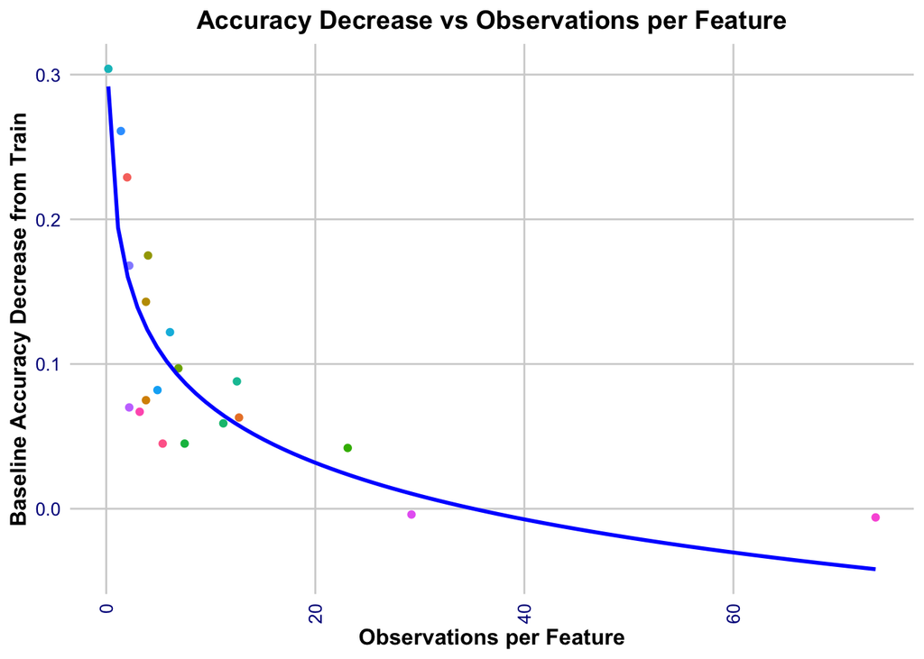

```r
# Create visuals for trending
datasets <- c('Spam Baseline', 'Covid Baseline', 'Spam Alt Baseline', 'Covid Alt Baseline',
              'Spam CFS', 'Covid CFS', 'Spam Alt CFS', 'Covid Alt CFS',
              'Spam RFE', 'Covid RFE', 'Spam Alt RFE', 'Covid Alt RFE',
              'Spam LASSO', 'Covid LASSO', 'Spam Alt LASSO', 'Covid Alt LASSO',
              'Spam RFECFS', 'Covid RFECFS', 'Spam Alt RFECFS', 'Covid Alt RFECFS')
var_ratio <- c(spam_num_records / spam_num_features, covid_num_records / covid_num_features, spam_alt_num_records / spam_alt_num_features, covid_alt_num_records / covid_alt_num_features,
               spam_num_records / spam_num_features1, covid_num_records / covid_num_features1, spam_alt_num_records / spam_alt_num_features1, covid_alt_num_records / covid_alt_num_features1,
               spam_num_records / spam_num_features2, covid_num_records / covid_num_features2, spam_alt_num_records / spam_alt_num_features2, covid_alt_num_records / covid_alt_num_features2,
               spam_num_records / spam_num_features3, covid_num_records / covid_num_features3, spam_alt_num_records / spam_alt_num_features3, covid_alt_num_records / covid_alt_num_features3,
               spam_num_records / spam_num_features4, covid_num_records / covid_num_features4, spam_alt_num_records / spam_alt_num_features4, covid_alt_num_records / covid_alt_num_features4)
accuracy_diff <- c(spam_baseline_accuracy_difference, covid_baseline_accuracy_difference, spam_alt_baseline_accuracy_difference, covid_alt_baseline_accuracy_difference,
                   spam_cfs_accuracy_difference, covid_cfs_accuracy_difference, spam_alt_cfs_accuracy_difference, covid_alt_cfs_accuracy_difference,
                   spam_rfe_accuracy_difference, covid_rfe_accuracy_difference, spam_alt_rfe_accuracy_difference, covid_alt_rfe_accuracy_difference,
                   spam_lasso_accuracy_difference, covid_lasso_accuracy_difference, spam_alt_lasso_accuracy_difference, covid_alt_lasso_accuracy_difference,
                   spam_cfs_rfe_accuracy_difference, covid_cfs_rfe_accuracy_difference, spam_alt_cfs_rfe_accuracy_difference, covid_alt_cfs_rfe_accuracy_difference)
sparsity <- c(spam_sparsity, covid_sparsity, spam_alt_sparsity, covid_alt_sparsity,
              spam_sparsity1, covid_sparsity1, spam_alt_sparsity1, covid_alt_sparsity1,
              spam_sparsity2, covid_sparsity2, spam_alt_sparsity2, covid_alt_sparsity2,
              NA, NA, NA, NA,
              spam_sparsity4, covid_sparsity4, spam_alt_sparsity4, covid_alt_sparsity4)

data <- data.frame(datasets, var_ratio, accuracy_diff, sparsity)

# Format numbers
data <- data %>%
  mutate(
    var_ratio = round(var_ratio, 1),
    accuracy_diff = round(accuracy_diff, 3),
    sparsity = round(sparsity, 1)
  )

ggplot(data, aes(x = var_ratio, y = accuracy_diff)) +
  geom_point(aes(color = datasets)) +
  # geom_text(aes(label = paste(datasets, "\nSparsity:", paste0(sparsity, "%"))), vjust = -0.3, hjust = 0) +
  geom_smooth(method = "lm", formula = y ~ log(x), se = FALSE, color = "blue") +
  labs(x = "Observations per Feature", y = "Baseline Accuracy Decrease from Train", title = "Accuracy Decrease vs Observations per Feature") +
  theme_minimal() +
  theme(
    axis.text.x = element_text(angle = 90, hjust = 1, vjust = 0.5, size = 10, color = "darkblue"),
    axis.text.y = element_text(size = 10, color = "darkblue"),
    axis.title.x = element_text(size = 12, face = "bold"),
    axis.title.y = element_text(size = 12, face = "bold"),
    plot.title = element_text(size = 14, face = "bold", hjust = 0.5),
    panel.grid.major = element_line(color = "lightgrey"),
    panel.grid.minor = element_blank()
  ) +
  guides(color = "none")
```

*Figure 6. Plot of overfitting as a function of observations per feature.*

# Conclusion

Feature selection is a crucial step in model building, and it often involves balancing several factors. Selecting fewer features tends to reduce overfitting by simplifying the model, which can sometimes lead to improved performance. However, there is no universally “best” feature elimination method, as the effectiveness of different techniques can vary depending on the specific dataset and problem. Ultimately, feature selection requires careful consideration of trade-offs between model complexity, test accuracy, overfitting, and the computational resources required for training and prediction. This balancing act ensures that the model remains both efficient and effective.

Despite the rise of large “big data” datasets with a high ratio of observations to features, feature selection remains highly relevant. Even with thousands of features, reducing the feature space can significantly streamline the modeling process. A smaller feature space requires less exploration, allowing models to more efficiently find optimal solutions. Additionally, pragmatic constraints such as documentation and managing dependencies make feature selection beneficial. By focusing on the most relevant features, the complexity of both model interpretation and maintenance can be reduced, leading to more efficient workflows and clearer insights.

## References

Basu, Indranil, and Subhadip Maji. 2022. “Multicollinearity Correction and Combined Feature Effect in Shapley Values.” In *Australasian Joint Conference on Artificial Intelligence*, 79–90. Springer.

Bühlmann, Peter, and Sara Van De Geer. 2011. *Statistics for High-Dimensional Data: Methods, Theory and Applications*. Springer Science & Business Media.

Das, Sanmay. 2001. “Filters, Wrappers and a Boosting-Based Hybrid for Feature Selection.” In *Icml*, 1:74–81. Citeseer.

DataTattle. 2024. “COVID-19 NLP Text Classification.” https://www.kaggle.com/datasets/datatattle/covid-19-nlp-text-classification; Kaggle.

Foster, Dean P, and Robert A Stine. 2004. “Variable Selection in Data Mining: Building a Predictive Model for Bankruptcy.” *Journal of the American Statistical Association* 99 (466): 303–13.

Guyon, Isabelle, Jason Weston, Stephen Barnhill, and Vladimir Vapnik. 2002. “Gene Selection for Cancer Classification Using Support Vector Machines.” *Machine Learning* 46: 389–422.

Hall, Mark A. 1999. “Correlation-Based Feature Selection for Machine Learning.” PhD thesis, The University of Waikato.

Hopkins, Reeber, Mark, and Jaap Suermondt. 1999. “Spambase.” UCI Machine Learning Repository.

Jović, Alan, Karla Brkić, and Nikola Bogunović. 2015. “A Review of Feature Selection Methods with Applications.” In *2015 38th International Convention on Information and Communication Technology, Electronics and Microelectronics (MIPRO)*, 1200–1205. Ieee.

Kohavi, Ron, and George H John. 1997. “Wrappers for Feature Subset Selection.” *Artificial Intelligence* 97 (1-2): 273–324.

Kou, Gang, Pei Yang, Yi Peng, Feng Xiao, Yang Chen, and Fawaz E Alsaadi. 2020. “Evaluation of Feature Selection Methods for Text Classification with Small Datasets Using Multiple Criteria Decision-Making Methods.” *Applied Soft Computing* 86: 105836.

Langley, Pat et al. 1994. “Selection of Relevant Features in Machine Learning.” In *Proceedings of the AAAI Fall Symposium on Relevance*, 184:245–71. California.

Li, Jundong, Kewei Cheng, Suhang Wang, Fred Morstatter, Robert P Trevino, Jiliang Tang, and Huan Liu. 2017. “Feature Selection: A Data Perspective.” *ACM Computing Surveys (CSUR)* 50 (6): 1–45.

Liu, Huan, and Hiroshi Motoda. 2012. *Feature Selection for Knowledge Discovery and Data Mining*. Vol. 454. Springer science & business media.

Miao, Jianyu, and Lingfeng Niu. 2016. “A Survey on Feature Selection.” *Procedia Computer Science* 91: 919–26.

Onnia, Vesa, Marius Tico, and Jukka Saarinen. 2001. “Feature Selection Method Using Neural Network.” In *Proceedings 2001 International Conference on Image Processing (Cat. No. 01CH37205)*, 1:513–16. IEEE.

Venkatesh, B, and J Anuradha. 2019. “A Review of Feature Selection and Its Methods.” *Cybernetics and Information Technologies* 19 (1): 3–26.